# **Problem Statement**

## Business Context

Renewable energy sources play an increasingly important role in the global energy mix, as the effort to reduce the environmental impact of energy production increases.

Out of all the renewable energy alternatives, wind energy is one of the most developed technologies worldwide. The U.S Department of Energy has put together a guide to achieving operational efficiency using predictive maintenance practices.

Predictive maintenance uses sensor information and analysis methods to measure and predict degradation and future component capability. The idea behind predictive maintenance is that failure patterns are predictable and if component failure can be predicted accurately and the component is replaced before it fails, the costs of operation and maintenance will be much lower.

The sensors fitted across different machines involved in the process of energy generation collect data related to various environmental factors (temperature, humidity, wind speed, etc.) and additional features related to various parts of the wind turbine (gearbox, tower, blades, break, etc.).

## Objective

“ReneWind” is a company working on improving the machinery/processes involved in the production of wind energy using machine learning and has collected data of generator failure of wind turbines using sensors. They have shared a ciphered version of the data, as the data collected through sensors is confidential (the type of data collected varies with companies). Data has 40 predictors, 20000 observations in the training set and 5000 in the test set.

The objective is to build various classification models, tune them, and find the best one that will help identify failures so that the generators could be repaired before failing/breaking to reduce the overall maintenance cost. The nature of predictions made by the classification model will translate as follows:

- True positives (TP) are failures correctly predicted by the model. These will result in repairing costs.
- False negatives (FN) are real failures where there is no detection by the model. These will result in replacement costs.
- False positives (FP) are detections where there is no failure. These will result in inspection costs.

It is given that the cost of repairing a generator is much less than the cost of replacing it, and the cost of inspection is less than the cost of repair.

“1” in the target variables should be considered as “failure” and “0” represents “No failure”.

## Data Description

The data provided is a transformed version of the original data which was collected using sensors.

- Train.csv - To be used for training and tuning of models.
- Test.csv - To be used only for testing the performance of the final best model.

Both the datasets consist of 40 predictor variables and 1 target variable.

# **Importing necessary libraries**

```python
import pandas as pd
import numpy as np
import tensorflow as tf
import seaborn as sns
import matplotlib.pyplot as plt
import time
import warnings

from tensorflow.keras.models import Sequential
from tensorflow.keras.layers import Dense,  Input, BatchNormalization, Dropout
from sklearn.metrics import accuracy_score, confusion_matrix, precision_score, recall_score, f1_score, auc, classification_report
from sklearn.model_selection import train_test_split
from sklearn.preprocessing import LabelEncoder, OneHotEncoder, StandardScaler
from sklearn.impute import SimpleImputer
from tensorflow.keras import backend

warnings.filterwarnings("ignore")
```

# **Loading the Data**

```python
df = pd.read_csv("Train.csv")
df_test  = pd.read_csv("Test.csv")
```

# **Data Overview**

#### Checking the shape of the datasets

```python
df.shape
```

```
(20000, 41)
```

- There are 20000 rows and 41 columns in the train data

```python
df_test.shape
```

```
(5000, 41)
```

- There are 5000 rows and 41 columns in the test data

#### Creating a copy of the datasets

```python
data = df.copy()
data_test  = df_test.copy()
```

#### Displaying the first 5 rows of the datasets

```python
data.head()
```

|  | V1 | V2 | V3 | V4 | V5 | V6 | V7 | V8 | V9 | V10 | ... | V32 | V33 | V34 | V35 | V36 | V37 | V38 | V39 | V40 | Target |
| --- | --- | --- | --- | --- | --- | --- | --- | --- | --- | --- | --- | --- | --- | --- | --- | --- | --- | --- | --- | --- | --- |
| 0 | -4.464606 | -4.679129 | 3.101546 | 0.506130 | -0.221083 | -2.032511 | -2.910870 | 0.050714 | -1.522351 | 3.761892 | ... | 3.059700 | -1.690440 | 2.846296 | 2.235198 | 6.667486 | 0.443809 | -2.369169 | 2.950578 | -3.480324 | 0 |
| 1 | 3.365912 | 3.653381 | 0.909671 | -1.367528 | 0.332016 | 2.358938 | 0.732600 | -4.332135 | 0.565695 | -0.101080 | ... | -1.795474 | 3.032780 | -2.467514 | 1.894599 | -2.297780 | -1.731048 | 5.908837 | -0.386345 | 0.616242 | 0 |
| 2 | -3.831843 | -5.824444 | 0.634031 | -2.418815 | -1.773827 | 1.016824 | -2.098941 | -3.173204 | -2.081860 | 5.392621 | ... | -0.257101 | 0.803550 | 4.086219 | 2.292138 | 5.360850 | 0.351993 | 2.940021 | 3.839160 | -4.309402 | 0 |
| 3 | 1.618098 | 1.888342 | 7.046143 | -1.147285 | 0.083080 | -1.529780 | 0.207309 | -2.493629 | 0.344926 | 2.118578 | ... | -3.584425 | -2.577474 | 1.363769 | 0.622714 | 5.550100 | -1.526796 | 0.138853 | 3.101430 | -1.277378 | 0 |
| 4 | -0.111440 | 3.872488 | -3.758361 | -2.982897 | 3.792714 | 0.544960 | 0.205433 | 4.848994 | -1.854920 | -6.220023 | ... | 8.265896 | 6.629213 | -10.068689 | 1.222987 | -3.229763 | 1.686909 | -2.163896 | -3.644622 | 6.510338 | 0 |

5 rows × 41 columns

```python
data_test.head()
```

|  | V1 | V2 | V3 | V4 | V5 | V6 | V7 | V8 | V9 | V10 | ... | V32 | V33 | V34 | V35 | V36 | V37 | V38 | V39 | V40 | Target |
| --- | --- | --- | --- | --- | --- | --- | --- | --- | --- | --- | --- | --- | --- | --- | --- | --- | --- | --- | --- | --- | --- |
| 0 | -0.613489 | -3.819640 | 2.202302 | 1.300420 | -1.184929 | -4.495964 | -1.835817 | 4.722989 | 1.206140 | -0.341909 | ... | 2.291204 | -5.411388 | 0.870073 | 0.574479 | 4.157191 | 1.428093 | -10.511342 | 0.454664 | -1.448363 | 0 |
| 1 | 0.389608 | -0.512341 | 0.527053 | -2.576776 | -1.016766 | 2.235112 | -0.441301 | -4.405744 | -0.332869 | 1.966794 | ... | -2.474936 | 2.493582 | 0.315165 | 2.059288 | 0.683859 | -0.485452 | 5.128350 | 1.720744 | -1.488235 | 0 |
| 2 | -0.874861 | -0.640632 | 4.084202 | -1.590454 | 0.525855 | -1.957592 | -0.695367 | 1.347309 | -1.732348 | 0.466500 | ... | -1.318888 | -2.997464 | 0.459664 | 0.619774 | 5.631504 | 1.323512 | -1.752154 | 1.808302 | 1.675748 | 0 |
| 3 | 0.238384 | 1.458607 | 4.014528 | 2.534478 | 1.196987 | -3.117330 | -0.924035 | 0.269493 | 1.322436 | 0.702345 | ... | 3.517918 | -3.074085 | -0.284220 | 0.954576 | 3.029331 | -1.367198 | -3.412140 | 0.906000 | -2.450889 | 0 |
| 4 | 5.828225 | 2.768260 | -1.234530 | 2.809264 | -1.641648 | -1.406698 | 0.568643 | 0.965043 | 1.918379 | -2.774855 | ... | 1.773841 | -1.501573 | -2.226702 | 4.776830 | -6.559698 | -0.805551 | -0.276007 | -3.858207 | -0.537694 | 0 |

5 rows × 41 columns

#### Checking the data types of the datasets

```python
data.info(verbose=True,show_counts=True)
```

```
<class 'pandas.core.frame.DataFrame'>
RangeIndex: 20000 entries, 0 to 19999
Data columns (total 41 columns):
 #   Column  Non-Null Count  Dtype
---  ------  --------------  -----
 0   V1      19982 non-null  float64
 1   V2      19982 non-null  float64
 2   V3      20000 non-null  float64
 3   V4      20000 non-null  float64
 4   V5      20000 non-null  float64
 5   V6      20000 non-null  float64
 6   V7      20000 non-null  float64
 7   V8      20000 non-null  float64
 8   V9      20000 non-null  float64
 9   V10     20000 non-null  float64
```

[output cut: 33 more lines]

- From the above observation, we can see there are 41 columns and 20000 rows in all except 2 features
- 40 columns have a data type of float64 except Target column which has an int64 data type. This has to be converted to match with the other columns

```python
data['Target'] = data['Target'].astype(float)
```

##### Checking for test data

```python
data_test.info()
```

```
<class 'pandas.core.frame.DataFrame'>
RangeIndex: 5000 entries, 0 to 4999
Data columns (total 41 columns):
 #   Column  Non-Null Count  Dtype
---  ------  --------------  -----
 0   V1      4995 non-null   float64
 1   V2      4994 non-null   float64
 2   V3      5000 non-null   float64
 3   V4      5000 non-null   float64
 4   V5      5000 non-null   float64
 5   V6      5000 non-null   float64
 6   V7      5000 non-null   float64
 7   V8      5000 non-null   float64
 8   V9      5000 non-null   float64
 9   V10     5000 non-null   float64
```

[output cut: 33 more lines]

- From the above observation, we can see there are 41 columns and 5000 rows in all except 2 features
- 40 columns have a data type of float64 except Target column which has an int64 data type. This has to be converted to match with the other columns

```python
data_test['Target'] = data_test['Target'].astype(float)
```

#### Let us check for duplicate values in the datasets

##### Checking train dataset

```python
data.duplicated().sum()
```

```
np.int64(0)
```

- There are no duplicate values in the train data

##### Checking test dataset

```python
data_test.duplicated().sum()
```

```
np.int64(0)
```

- There are no duplicate values in the test data

#### Checking for missing values

```python
data.isnull().sum()
```

```
V1        18
V2        18
V3         0
V4         0
V5         0
V6         0
V7         0
V8         0
V9         0
V10        0
V11        0
V12        0
V13        0
V14        0
V15        0
V16        0
V17        0
V18        0
V19        0
V20        0
V21        0
V22        0
V23        0
V24        0
V25        0
V26        0
V27        0
V28        0
V29        0
V30        0
V31        0
V32        0
V33        0
V34        0
V35        0
V36        0
V37        0
V38        0
V39        0
V40        0
Target     0
dtype: int64
```

- We have observed there are missing data in V1 and V2 features

```python
data_test.isnull().sum()
```

```
V1        5
V2        6
V3        0
V4        0
V5        0
V6        0
V7        0
V8        0
V9        0
V10       0
V11       0
V12       0
V13       0
V14       0
V15       0
V16       0
V17       0
V18       0
V19       0
V20       0
V21       0
V22       0
V23       0
V24       0
V25       0
V26       0
V27       0
V28       0
V29       0
V30       0
V31       0
V32       0
V33       0
V34       0
V35       0
V36       0
V37       0
V38       0
V39       0
V40       0
Target    0
dtype: int64
```

- There are missing values in the test data

#### Statistical summary of the dataset

```python
data.describe().T
```

|  | count | mean | std | min | 25% | 50% | 75% | max |
| --- | --- | --- | --- | --- | --- | --- | --- | --- |
| V1 | 19982.0 | -0.271996 | 3.441625 | -11.876451 | -2.737146 | -0.747917 | 1.840112 | 15.493002 |
| V2 | 19982.0 | 0.440430 | 3.150784 | -12.319951 | -1.640674 | 0.471536 | 2.543967 | 13.089269 |
| V3 | 20000.0 | 2.484699 | 3.388963 | -10.708139 | 0.206860 | 2.255786 | 4.566165 | 17.090919 |
| V4 | 20000.0 | -0.083152 | 3.431595 | -15.082052 | -2.347660 | -0.135241 | 2.130615 | 13.236381 |
| V5 | 20000.0 | -0.053752 | 2.104801 | -8.603361 | -1.535607 | -0.101952 | 1.340480 | 8.133797 |
| V6 | 20000.0 | -0.995443 | 2.040970 | -10.227147 | -2.347238 | -1.000515 | 0.380330 | 6.975847 |
| V7 | 20000.0 | -0.879325 | 1.761626 | -7.949681 | -2.030926 | -0.917179 | 0.223695 | 8.006091 |
| V8 | 20000.0 | -0.548195 | 3.295756 | -15.657561 | -2.642665 | -0.389085 | 1.722965 | 11.679495 |
| V9 | 20000.0 | -0.016808 | 2.160568 | -8.596313 | -1.494973 | -0.067597 | 1.409203 | 8.137580 |
| V10 | 20000.0 | -0.012998 | 2.193201 | -9.853957 | -1.411212 | 0.100973 | 1.477045 | 8.108472 |
| V11 | 20000.0 | -1.895393 | 3.124322 | -14.832058 | -3.922404 | -1.921237 | 0.118906 | 11.826433 |
| V12 | 20000.0 | 1.604825 | 2.930454 | -12.948007 | -0.396514 | 1.507841 | 3.571454 | 15.080698 |
| V13 | 20000.0 | 1.580486 | 2.874658 | -13.228247 | -0.223545 | 1.637185 | 3.459886 | 15.419616 |
| V14 | 20000.0 | -0.950632 | 1.789651 | -7.738593 | -2.170741 | -0.957163 | 0.270677 | 5.670664 |
| V15 | 20000.0 | -2.414993 | 3.354974 | -16.416606 | -4.415322 | -2.382617 | -0.359052 | 12.246455 |
| V16 | 20000.0 | -2.925225 | 4.221717 | -20.374158 | -5.634240 | -2.682705 | -0.095046 | 13.583212 |
| V17 | 20000.0 | -0.134261 | 3.345462 | -14.091184 | -2.215611 | -0.014580 | 2.068751 | 16.756432 |
| V18 | 20000.0 | 1.189347 | 2.592276 | -11.643994 | -0.403917 | 0.883398 | 2.571770 | 13.179863 |
| V19 | 20000.0 | 1.181808 | 3.396925 | -13.491784 | -1.050168 | 1.279061 | 3.493299 | 13.237742 |
| V20 | 20000.0 | 0.023608 | 3.669477 | -13.922659 | -2.432953 | 0.033415 | 2.512372 | 16.052339 |
| V21 | 20000.0 | -3.611252 | 3.567690 | -17.956231 | -5.930360 | -3.532888 | -1.265884 | 13.840473 |
| V22 | 20000.0 | 0.951835 | 1.651547 | -10.122095 | -0.118127 | 0.974687 | 2.025594 | 7.409856 |
| V23 | 20000.0 | -0.366116 | 4.031860 | -14.866128 | -3.098756 | -0.262093 | 2.451750 | 14.458734 |
| V24 | 20000.0 | 1.134389 | 3.912069 | -16.387147 | -1.468062 | 0.969048 | 3.545975 | 17.163291 |
| V25 | 20000.0 | -0.002186 | 2.016740 | -8.228266 | -1.365178 | 0.025050 | 1.397112 | 8.223389 |
| V26 | 20000.0 | 1.873785 | 3.435137 | -11.834271 | -0.337863 | 1.950531 | 4.130037 | 16.836410 |
| V27 | 20000.0 | -0.612413 | 4.368847 | -14.904939 | -3.652323 | -0.884894 | 2.189177 | 17.560404 |
| V28 | 20000.0 | -0.883218 | 1.917713 | -9.269489 | -2.171218 | -0.891073 | 0.375884 | 6.527643 |
| V29 | 20000.0 | -0.985625 | 2.684365 | -12.579469 | -2.787443 | -1.176181 | 0.629773 | 10.722055 |
| V30 | 20000.0 | -0.015534 | 3.005258 | -14.796047 | -1.867114 | 0.184346 | 2.036229 | 12.505812 |
| V31 | 20000.0 | 0.486842 | 3.461384 | -13.722760 | -1.817772 | 0.490304 | 2.730688 | 17.255090 |
| V32 | 20000.0 | 0.303799 | 5.500400 | -19.876502 | -3.420469 | 0.052073 | 3.761722 | 23.633187 |
| V33 | 20000.0 | 0.049825 | 3.575285 | -16.898353 | -2.242857 | -0.066249 | 2.255134 | 16.692486 |
| V34 | 20000.0 | -0.462702 | 3.183841 | -17.985094 | -2.136984 | -0.255008 | 1.436935 | 14.358213 |
| V35 | 20000.0 | 2.229620 | 2.937102 | -15.349803 | 0.336191 | 2.098633 | 4.064358 | 15.291065 |
| V36 | 20000.0 | 1.514809 | 3.800860 | -14.833178 | -0.943809 | 1.566526 | 3.983939 | 19.329576 |
| V37 | 20000.0 | 0.011316 | 1.788165 | -5.478350 | -1.255819 | -0.128435 | 1.175533 | 7.467006 |
| V38 | 20000.0 | -0.344025 | 3.948147 | -17.375002 | -2.987638 | -0.316849 | 2.279399 | 15.289923 |
| V39 | 20000.0 | 0.890653 | 1.753054 | -6.438880 | -0.272250 | 0.919261 | 2.057540 | 7.759877 |
| V40 | 20000.0 | -0.875630 | 3.012155 | -11.023935 | -2.940193 | -0.920806 | 1.119897 | 10.654265 |
| Target | 20000.0 | 0.055500 | 0.228959 | 0.000000 | 0.000000 | 0.000000 | 0.000000 | 1.000000 |

# **Exploratory Data Analysis**

## Univariate analysis

```python
def histogram_boxplot(data, feature, figsize=(12, 7), kde=False, bins=None):
    """
    Boxplot and histogram combined

    data: dataframe
    feature: dataframe column
    figsize: size of figure (default (12,7))
    kde: whether to the show density curve (default False)
    bins: number of bins for histogram (default None)
    """
    f2, (ax_box2, ax_hist2) = plt.subplots(
        nrows=2,  # Number of rows of the subplot grid= 2
        sharex=True,  # x-axis will be shared among all subplots
        gridspec_kw={"height_ratios": (0.25, 0.75)},
        figsize=figsize,
    )  # creating the 2 subplots
    sns.boxplot(
        data= data, x=feature, ax= ax_box2, showmeans=True, color="violet"
    )  # boxplot will be created and a star will indicate the mean value of the column
    sns.histplot(
        data=data, x=feature, kde=kde, ax=ax_hist2, bins=bins, palette="winter"
    ) if bins else sns.histplot(
        data=data, x=feature, kde=kde, ax=ax_hist2
    )  # For histogram
    ax_hist2.axvline(
        data[feature].mean(), color="green", linestyle="--"
    )  # Add mean to the histogram
    ax_hist2.axvline(
        data[feature].median(), color="black", linestyle="-"
    )  # Add median to the histogram
```

#### Analysing variables V1 to V29

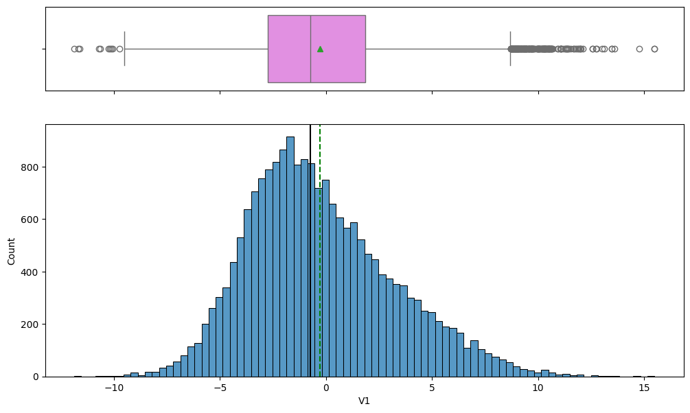

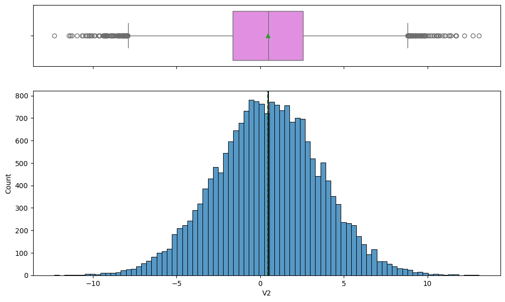

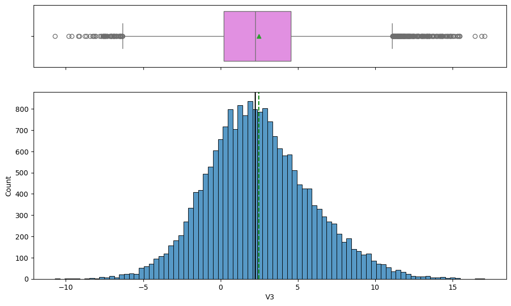

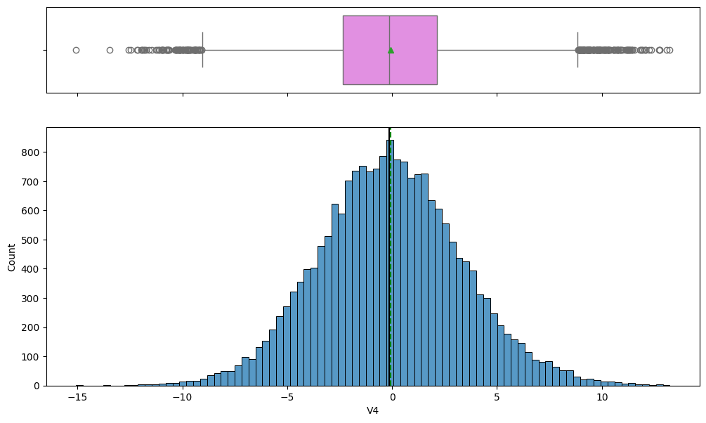

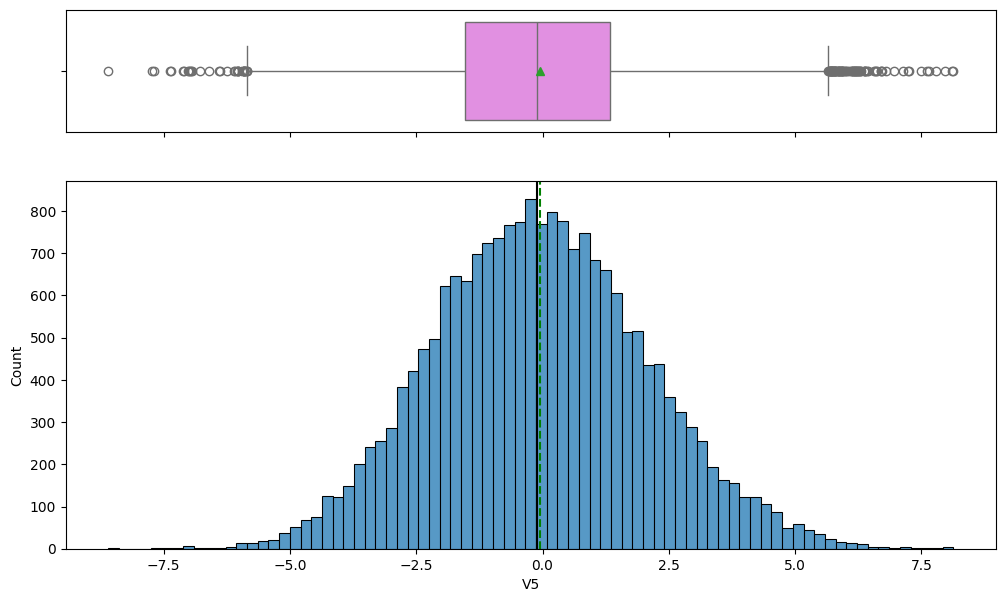

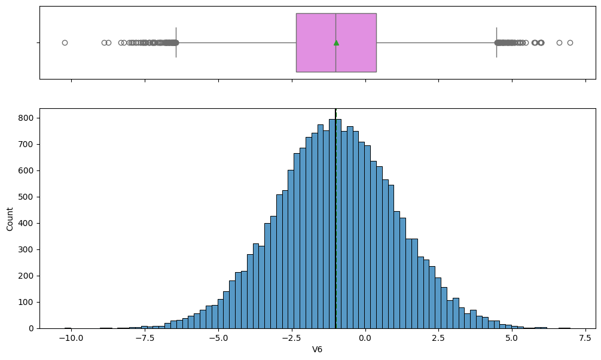

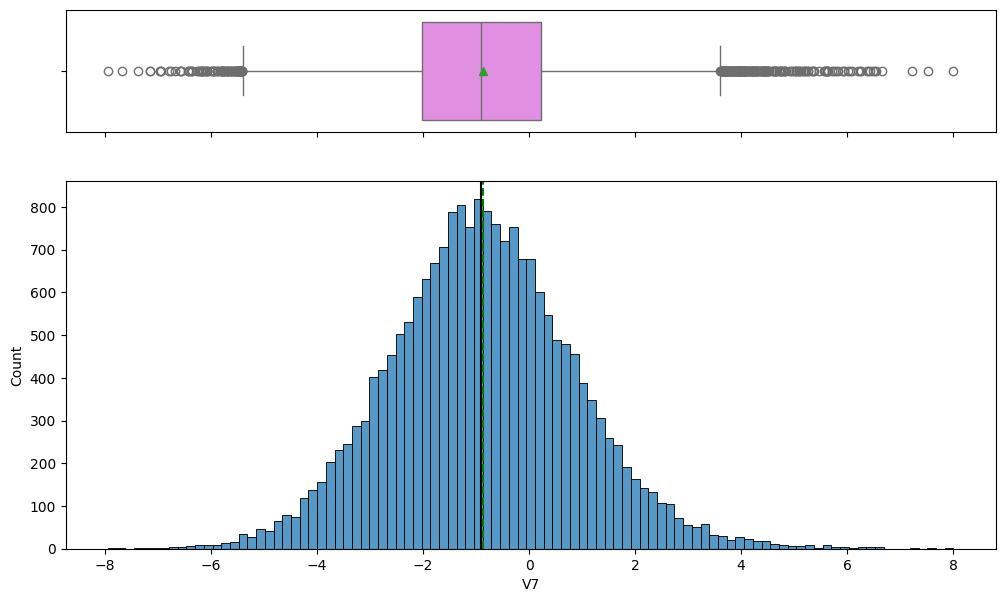

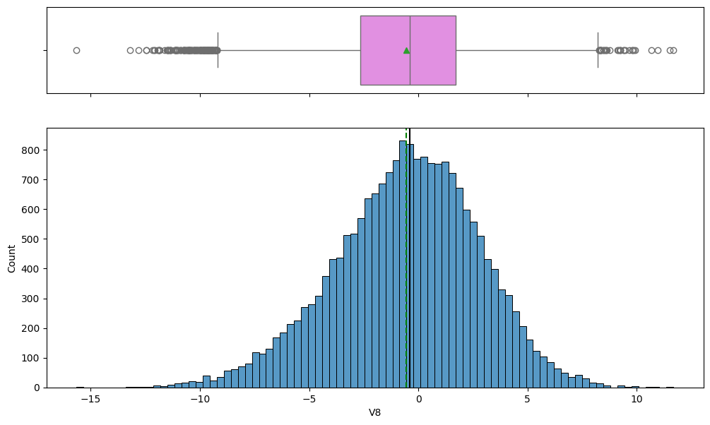

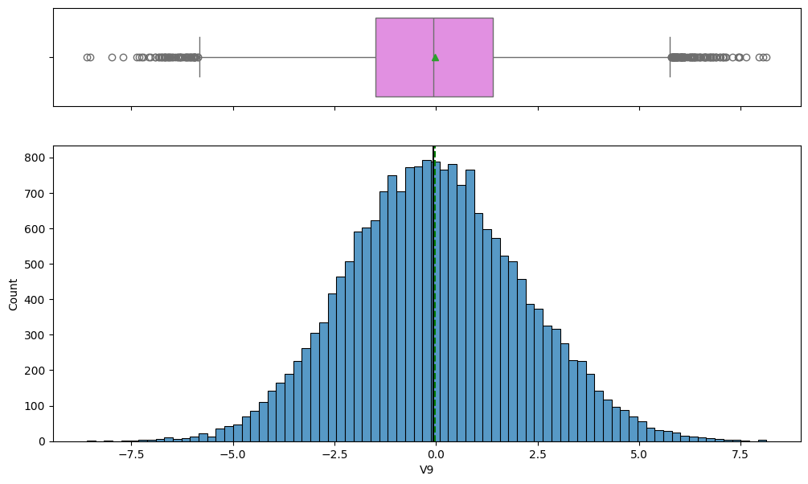

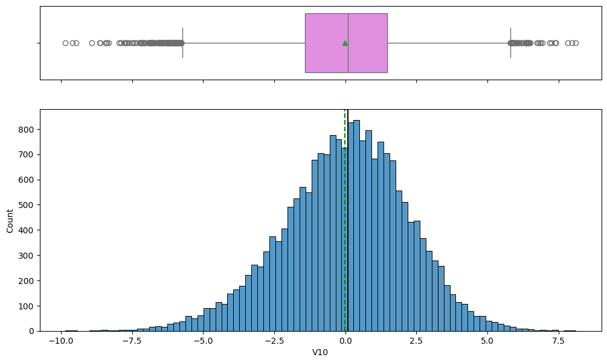

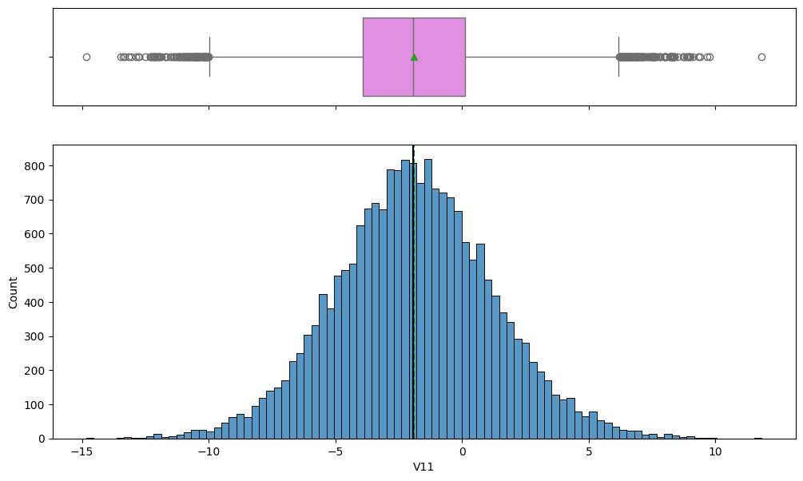

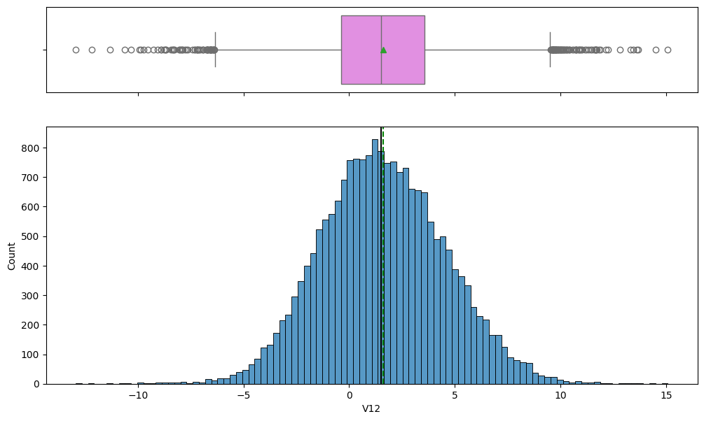

[28 more figures not shown]

```python
for column in df.iloc[:,0:40].columns:
    histogram_boxplot(df,column,figsize=(12,7),kde=False,bins=None)
```

- All the variable from V1-V40 have outliers on both the upper and lower quatile
- All the variables from V1-V40 seem to have a normal distribution due to the bell shaped graph

##### Checking distribution for Target variable

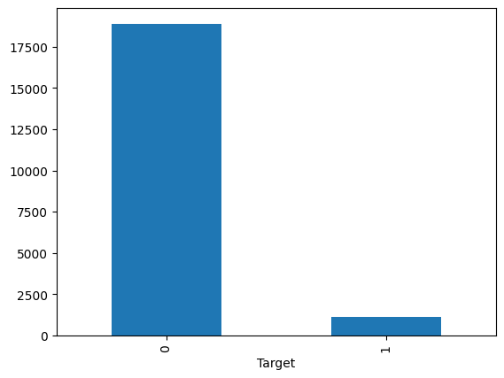

```python
df['Target'].value_counts().plot(kind='bar')
```

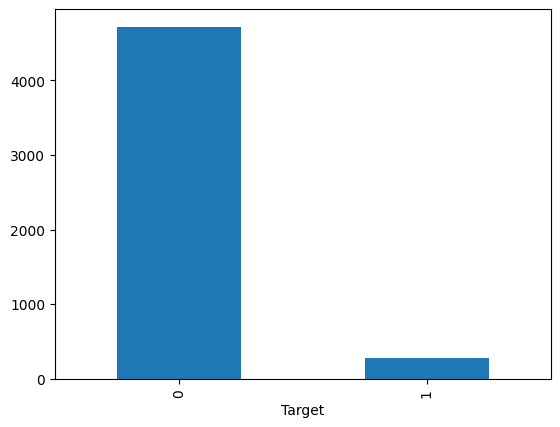

```python
df_test['Target'].value_counts().plot(kind='bar')
```

- On the test data there are approximately 250 generators marked as failed and need replacement

## Bivariate Analysis

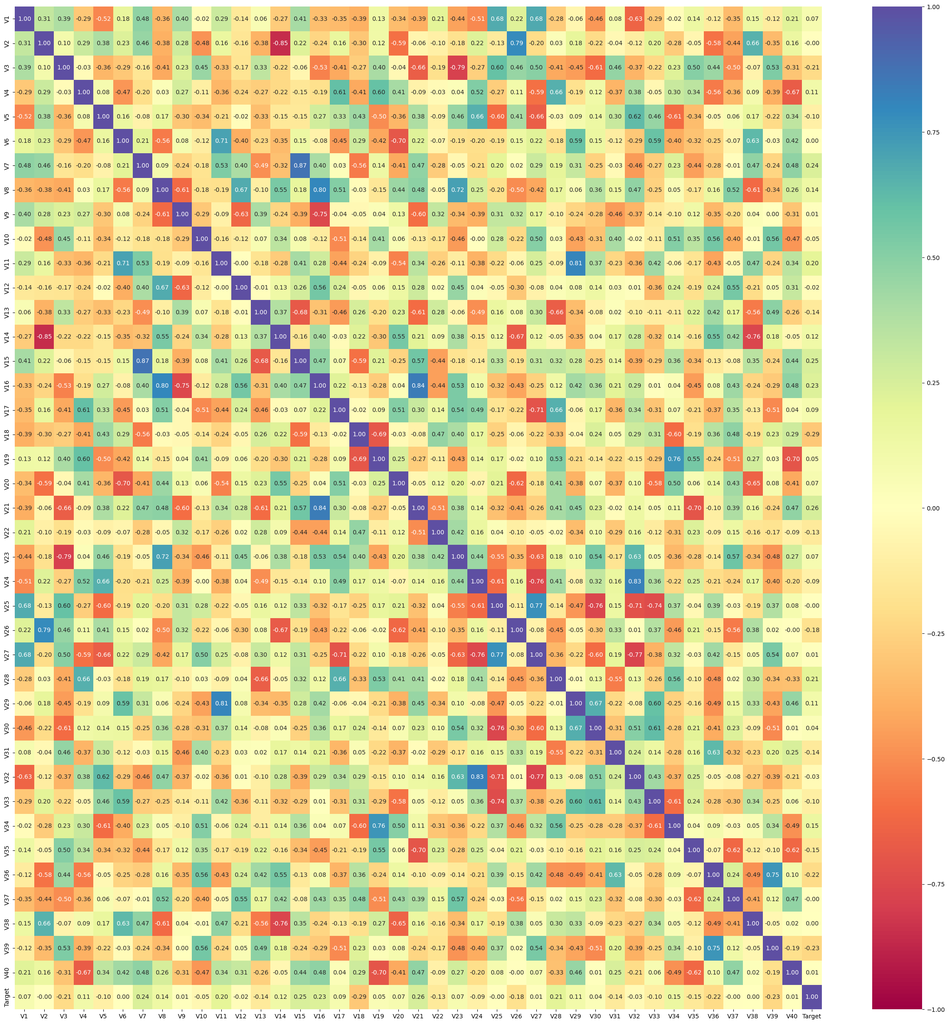

```python
plt.figure(figsize=(30,30))
sns.heatmap(
    data.corr(numeric_only=True),
    annot=True,
    vmin=-1,
    vmax=1,
    fmt='.2f',
    cmap='Spectral'
)
plt.show()
```

# **Data Preprocessing**

#### Preparing for modeling

```python
X = data.drop(columns = ['Target'], axis=1)
y = data['Target']
```

```python
X_train, X_val, y_train, y_val = train_test_split(
    X,
    y,
    test_size=0.25,
    random_state=1,
    stratify=y
)
```

```python
X_train.shape
```

```
(15000, 40)
```

```python
X_val.shape
```

```
(5000, 40)
```

```python
X_test = data_test.drop(columns=['Target'],axis=1)
y_test = data_test['Target']
```

```python
X_test.shape
```

```
(5000, 40)
```

#### Imputing missing values

```python
imputer = SimpleImputer(strategy="median")
```

```python
X_train = pd.DataFrame(imputer.fit_transform(X_train),columns=X_train.columns)

X_val = pd.DataFrame(imputer.fit_transform(X_val), columns=X_train.columns)

X_test = pd.DataFrame(imputer.fit_transform(X_test), columns=X_train.columns)
```

```python
X_train.isna().sum()
```

```
V1     0
V2     0
V3     0
V4     0
V5     0
V6     0
V7     0
V8     0
V9     0
V10    0
V11    0
V12    0
V13    0
V14    0
V15    0
V16    0
V17    0
V18    0
V19    0
V20    0
V21    0
V22    0
V23    0
V24    0
V25    0
V26    0
V27    0
V28    0
V29    0
V30    0
V31    0
V32    0
V33    0
V34    0
V35    0
V36    0
V37    0
V38    0
V39    0
V40    0
dtype: int64
```

```python
X_val.isna().sum()
```

```
V1     0
V2     0
V3     0
V4     0
V5     0
V6     0
V7     0
V8     0
V9     0
V10    0
V11    0
V12    0
V13    0
V14    0
V15    0
V16    0
V17    0
V18    0
V19    0
V20    0
V21    0
V22    0
V23    0
V24    0
V25    0
V26    0
V27    0
V28    0
V29    0
V30    0
V31    0
V32    0
V33    0
V34    0
V35    0
V36    0
V37    0
V38    0
V39    0
V40    0
dtype: int64
```

```python
X_test.isna().sum()
```

```
V1     0
V2     0
V3     0
V4     0
V5     0
V6     0
V7     0
V8     0
V9     0
V10    0
V11    0
V12    0
V13    0
V14    0
V15    0
V16    0
V17    0
V18    0
V19    0
V20    0
V21    0
V22    0
V23    0
V24    0
V25    0
V26    0
V27    0
V28    0
V29    0
V30    0
V31    0
V32    0
V33    0
V34    0
V35    0
V36    0
V37    0
V38    0
V39    0
V40    0
dtype: int64
```

```python
y_train = y_train.to_numpy()
y_val   = y_val.to_numpy()
y_test  = y_test.to_numpy()
```

- There are not no null values. We can proceed with building a model

# **Model Building**

## Model Evaluation Criterion

#### Creating reusable functions

```python
# check the model preformance
def model_perf_classify(model,predictors,target, threshold=0.5):

    """
    model: classifier
    predictors: independent variables
    target: dependent variable
    threshold: threshold for classifying the observation as class 1
    """

    # checking which probabilities are greater than threshold
    pred = model.predict(predictors) > threshold

    accuracy  = accuracy_score(target,pred)
    recall    = recall_score(target,pred,average='macro')
    precision = precision_score(target,pred, average='macro')
    f1        = f1_score(target,pred,average='macro')

    return pd.DataFrame({"Accuracy": accuracy,"Recall": recall,"Precision":precision," F1 Score":[ f1] }, index = [0])

def plot(history,name):
    """
    Function to plot loss/accuracy

    history: an object which stores the metrics and losses.
    name: can be one of Loss or Accuracy
    """

    fig, ax = plt.subplots()
    plt.plot(history.history[name])
    plt.plot(history.history['val_'+name])
    plt.title('Model' + name.capitalize())
    plt.ylabel(name.capitalize())
    plt.xlabel('Epoch')
    fig.legend(['Train','Validation'],loc='outside right upper')
```

## Initial Model Building (Model 0)

- Let's start with a neural network consisting of
  - just one hidden layer
  - activation function of ReLU
  - SGD as the optimizer

```python
epochs = 25
batch_size = 64
```

```python
tf.keras.backend.clear_session()
```

```python
model_0 = Sequential()
model_0.add(Dense(16,activation='relu',input_dim=X_train.shape[1]))
model_0.add(Dense(1,activation='sigmoid'))
```

```python
model_0.summary()
```

```
Model: "sequential"
```

```
┏━━━━━━━━━━━━━━━━━━━━━━━━━━━━━━━━━┳━━━━━━━━━━━━━━━━━━━━━━━━┳━━━━━━━━━━━━━━━┓
┃ Layer (type)                    ┃ Output Shape           ┃       Param # ┃
┡━━━━━━━━━━━━━━━━━━━━━━━━━━━━━━━━━╇━━━━━━━━━━━━━━━━━━━━━━━━╇━━━━━━━━━━━━━━━┩
│ dense (Dense)                   │ (None, 16)             │           656 │
├─────────────────────────────────┼────────────────────────┼───────────────┤
│ dense_1 (Dense)                 │ (None, 1)              │            17 │
└─────────────────────────────────┴────────────────────────┴───────────────┘
```

```
 Total params: 673 (2.63 KB)
```

```
 Trainable params: 673 (2.63 KB)
```

```
 Non-trainable params: 0 (0.00 B)
```

```python
optimizer = tf.keras.optimizers.SGD()
model_0.compile(loss='binary_crossentropy',optimizer=optimizer,metrics=['recall'])
```

```python
start = time.time()
history = model_0.fit(X_train,y_train,validation_data=(X_val,y_val), batch_size=batch_size,epochs=epochs)
end=time.time()
```

```
235/235 ━━━━━━━━━━━━━━━━━━━━ 4s 11ms/step - loss: 0.5060 - recall: 0.4336 - val_loss: 0.1337 - val_recall: 0.5216
235/235 ━━━━━━━━━━━━━━━━━━━━ 2s 7ms/step - loss: 0.1181 - recall: 0.5497 - val_loss: 0.1058 - val_recall: 0.6079
235/235 ━━━━━━━━━━━━━━━━━━━━ 2s 7ms/step - loss: 0.1013 - recall: 0.6285 - val_loss: 0.0946 - val_recall: 0.6727
235/235 ━━━━━━━━━━━━━━━━━━━━ 2s 7ms/step - loss: 0.0836 - recall: 0.6833 - val_loss: 0.0889 - val_recall: 0.7050
235/235 ━━━━━━━━━━━━━━━━━━━━ 2s 7ms/step - loss: 0.0823 - recall: 0.6970 - val_loss: 0.0850 - val_recall: 0.7266
235/235 ━━━━━━━━━━━━━━━━━━━━ 2s 7ms/step - loss: 0.0813 - recall: 0.7116 - val_loss: 0.0821 - val_recall: 0.7338
235/235 ━━━━━━━━━━━━━━━━━━━━ 1s 6ms/step - loss: 0.0744 - recall: 0.7126 - val_loss: 0.0802 - val_recall: 0.7626
235/235 ━━━━━━━━━━━━━━━━━━━━ 1s 6ms/step - loss: 0.0735 - recall: 0.7674 - val_loss: 0.0786 - val_recall: 0.7662
235/235 ━━━━━━━━━━━━━━━━━━━━ 1s 6ms/step - loss: 0.0654 - recall: 0.7573 - val_loss: 0.0777 - val_recall: 0.7842
235/235 ━━━━━━━━━━━━━━━━━━━━ 1s 6ms/step - loss: 0.0662 - recall: 0.7726 - val_loss: 0.0763 - val_recall: 0.7878
235/235 ━━━━━━━━━━━━━━━━━━━━ 2s 6ms/step - loss: 0.0666 - recall: 0.7701 - val_loss: 0.0749 - val_recall: 0.7878
235/235 ━━━━━━━━━━━━━━━━━━━━ 2s 7ms/step - loss: 0.0647 - recall: 0.7737 - val_loss: 0.0741 - val_recall: 0.7914
235/235 ━━━━━━━━━━━━━━━━━━━━ 1s 6ms/step - loss: 0.0579 - recall: 0.8052 - val_loss: 0.0732 - val_recall: 0.7950
235/235 ━━━━━━━━━━━━━━━━━━━━ 1s 5ms/step - loss: 0.0684 - recall: 0.7716 - val_loss: 0.0726 - val_recall: 0.7914
235/235 ━━━━━━━━━━━━━━━━━━━━ 1s 5ms/step - loss: 0.0689 - recall: 0.7671 - val_loss: 0.0719 - val_recall: 0.7950
235/235 ━━━━━━━━━━━━━━━━━━━━ 1s 6ms/step - loss: 0.0613 - recall: 0.7837 - val_loss: 0.0713 - val_recall: 0.8094
235/235 ━━━━━━━━━━━━━━━━━━━━ 2s 7ms/step - loss: 0.0627 - recall: 0.8025 - val_loss: 0.0709 - val_recall: 0.8129
235/235 ━━━━━━━━━━━━━━━━━━━━ 1s 6ms/step - loss: 0.0642 - recall: 0.7858 - val_loss: 0.0702 - val_recall: 0.8058
235/235 ━━━━━━━━━━━━━━━━━━━━ 2s 6ms/step - loss: 0.0610 - recall: 0.7817 - val_loss: 0.0700 - val_recall: 0.8129
235/235 ━━━━━━━━━━━━━━━━━━━━ 1s 6ms/step - loss: 0.0533 - recall: 0.8112 - val_loss: 0.0693 - val_recall: 0.8237
235/235 ━━━━━━━━━━━━━━━━━━━━ 1s 6ms/step - loss: 0.0581 - recall: 0.8096 - val_loss: 0.0692 - val_recall: 0.8237
235/235 ━━━━━━━━━━━━━━━━━━━━ 2s 6ms/step - loss: 0.0573 - recall: 0.8139 - val_loss: 0.0688 - val_recall: 0.8237
235/235 ━━━━━━━━━━━━━━━━━━━━ 1s 6ms/step - loss: 0.0558 - recall: 0.8092 - val_loss: 0.0683 - val_recall: 0.8237
235/235 ━━━━━━━━━━━━━━━━━━━━ 1s 6ms/step - loss: 0.0566 - recall: 0.8177 - val_loss: 0.0682 - val_recall: 0.8201
235/235 ━━━━━━━━━━━━━━━━━━━━ 2s 6ms/step - loss: 0.0597 - recall: 0.8107 - val_loss: 0.0682 - val_recall: 0.8237
```

```python
print("Time taken in seconds", end-start)
```

```
Time taken in seconds 39.564356327056885
```

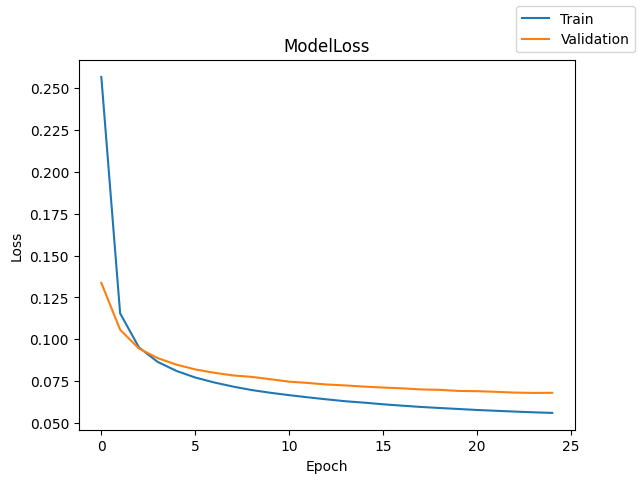

```python
plot(history,'loss')
```

```python
model_0_train_perf = model_perf_classify(model_0,X_train,y_train)
model_0_train_perf
```

```
469/469 ━━━━━━━━━━━━━━━━━━━━ 1s 2ms/step
```

|  | Accuracy | Recall | Precision | F1 Score |
| --- | --- | --- | --- | --- |
| 0 | 0.988933 | 0.910422 | 0.982004 | 0.942977 |

```python
model_0_val_perf = model_perf_classify(model_0,X_val,y_val)
model_0_val_perf
```

```
157/157 ━━━━━━━━━━━━━━━━━━━━ 1s 4ms/step
```

|  | Accuracy | Recall | Precision | F1 Score |
| --- | --- | --- | --- | --- |
| 0 | 0.9882 | 0.910812 | 0.973934 | 0.939829 |

#### Checking the classification reports

```python
y_train_pred_0 = model_0.predict(X_train)
y_val_pred_0   = model_0.predict(X_val)
```

```
469/469 ━━━━━━━━━━━━━━━━━━━━ 1s 3ms/step
157/157 ━━━━━━━━━━━━━━━━━━━━ 0s 2ms/step
```

```python
print("Classification Report - Train dataset Model 0",end="\n\n")
cr_train_model_0 = classification_report(y_train,y_train_pred_0>0.5)
print(cr_train_model_0)
```

```
Classification Report - Train dataset Model 0

              precision    recall  f1-score   support

         0.0       0.99      1.00      0.99     14168
         1.0       0.97      0.82      0.89       832

    accuracy                           0.99     15000
   macro avg       0.98      0.91      0.94     15000
weighted avg       0.99      0.99      0.99     15000
```

```python
print("Classification Report - Validation dataset Model 0",end="\n\n")
cr_test_model_0 = classification_report(y_val,y_val_pred_0>0.5)
print(cr_test_model_0)
```

```
Classification Report - Validation dataset Model 0

              precision    recall  f1-score   support

         0.0       0.99      1.00      0.99      4722
         1.0       0.96      0.82      0.89       278

    accuracy                           0.99      5000
   macro avg       0.97      0.91      0.94      5000
weighted avg       0.99      0.99      0.99      5000
```

# **Model Performance Improvement**

## Model 1

```python
tf.keras.backend.clear_session()
```

```python
model_1 = Sequential()
model_1.add(Dense(16,activation='relu',input_dim=X_train.shape[1]))
model_1.add(Dense(8,activation='relu'))
model_1.add(Dense(1,activation='sigmoid'))
```

```python
model_1.summary()
```

```
Model: "sequential"
```

```
┏━━━━━━━━━━━━━━━━━━━━━━━━━━━━━━━━━┳━━━━━━━━━━━━━━━━━━━━━━━━┳━━━━━━━━━━━━━━━┓
┃ Layer (type)                    ┃ Output Shape           ┃       Param # ┃
┡━━━━━━━━━━━━━━━━━━━━━━━━━━━━━━━━━╇━━━━━━━━━━━━━━━━━━━━━━━━╇━━━━━━━━━━━━━━━┩
│ dense (Dense)                   │ (None, 16)             │           656 │
├─────────────────────────────────┼────────────────────────┼───────────────┤
│ dense_1 (Dense)                 │ (None, 8)              │           136 │
├─────────────────────────────────┼────────────────────────┼───────────────┤
│ dense_2 (Dense)                 │ (None, 1)              │             9 │
└─────────────────────────────────┴────────────────────────┴───────────────┘
```

```
 Total params: 801 (3.13 KB)
```

```
 Trainable params: 801 (3.13 KB)
```

```
 Non-trainable params: 0 (0.00 B)
```

```python
optimizer = tf.keras.optimizers.SGD()
model_1.compile(loss='binary_crossentropy',optimizer=optimizer,metrics=['recall'])
```

```python
start = time.time()
history_1 = model_1.fit(X_train,y_train,validation_data=(X_val,y_val),batch_size=batch_size,epochs=epochs)
end   = time.time()
```

```
235/235 ━━━━━━━━━━━━━━━━━━━━ 5s 15ms/step - loss: 0.3850 - recall: 0.0132 - val_loss: 0.1684 - val_recall: 0.0791
235/235 ━━━━━━━━━━━━━━━━━━━━ 2s 7ms/step - loss: 0.1549 - recall: 0.0947 - val_loss: 0.1355 - val_recall: 0.1367
235/235 ━━━━━━━━━━━━━━━━━━━━ 2s 7ms/step - loss: 0.1368 - recall: 0.1405 - val_loss: 0.1226 - val_recall: 0.1942
235/235 ━━━━━━━━━━━━━━━━━━━━ 2s 8ms/step - loss: 0.1197 - recall: 0.1984 - val_loss: 0.1150 - val_recall: 0.2842
235/235 ━━━━━━━━━━━━━━━━━━━━ 2s 7ms/step - loss: 0.1213 - recall: 0.2978 - val_loss: 0.1102 - val_recall: 0.3633
235/235 ━━━━━━━━━━━━━━━━━━━━ 2s 7ms/step - loss: 0.1069 - recall: 0.3620 - val_loss: 0.1064 - val_recall: 0.4209
235/235 ━━━━━━━━━━━━━━━━━━━━ 2s 8ms/step - loss: 0.1035 - recall: 0.4510 - val_loss: 0.1028 - val_recall: 0.4676
235/235 ━━━━━━━━━━━━━━━━━━━━ 2s 7ms/step - loss: 0.0933 - recall: 0.4988 - val_loss: 0.0998 - val_recall: 0.5072
235/235 ━━━━━━━━━━━━━━━━━━━━ 2s 7ms/step - loss: 0.0878 - recall: 0.5189 - val_loss: 0.0971 - val_recall: 0.5612
235/235 ━━━━━━━━━━━━━━━━━━━━ 2s 7ms/step - loss: 0.0855 - recall: 0.5555 - val_loss: 0.0945 - val_recall: 0.5971
235/235 ━━━━━━━━━━━━━━━━━━━━ 2s 7ms/step - loss: 0.0837 - recall: 0.6133 - val_loss: 0.0918 - val_recall: 0.6115
235/235 ━━━━━━━━━━━━━━━━━━━━ 2s 7ms/step - loss: 0.0830 - recall: 0.5934 - val_loss: 0.0895 - val_recall: 0.6187
235/235 ━━━━━━━━━━━━━━━━━━━━ 1s 6ms/step - loss: 0.0840 - recall: 0.6185 - val_loss: 0.0878 - val_recall: 0.6619
235/235 ━━━━━━━━━━━━━━━━━━━━ 2s 6ms/step - loss: 0.0814 - recall: 0.5825 - val_loss: 0.0862 - val_recall: 0.6655
235/235 ━━━━━━━━━━━━━━━━━━━━ 2s 7ms/step - loss: 0.0828 - recall: 0.6444 - val_loss: 0.0844 - val_recall: 0.6691
235/235 ━━━━━━━━━━━━━━━━━━━━ 2s 7ms/step - loss: 0.0768 - recall: 0.6665 - val_loss: 0.0828 - val_recall: 0.6727
235/235 ━━━━━━━━━━━━━━━━━━━━ 2s 7ms/step - loss: 0.0753 - recall: 0.6700 - val_loss: 0.0816 - val_recall: 0.6906
235/235 ━━━━━━━━━━━━━━━━━━━━ 2s 7ms/step - loss: 0.0628 - recall: 0.7230 - val_loss: 0.0803 - val_recall: 0.7050
235/235 ━━━━━━━━━━━━━━━━━━━━ 2s 7ms/step - loss: 0.0704 - recall: 0.6926 - val_loss: 0.0788 - val_recall: 0.7194
235/235 ━━━━━━━━━━━━━━━━━━━━ 2s 8ms/step - loss: 0.0708 - recall: 0.7028 - val_loss: 0.0775 - val_recall: 0.7266
235/235 ━━━━━━━━━━━━━━━━━━━━ 2s 8ms/step - loss: 0.0637 - recall: 0.7169 - val_loss: 0.0763 - val_recall: 0.7482
235/235 ━━━━━━━━━━━━━━━━━━━━ 2s 7ms/step - loss: 0.0657 - recall: 0.7155 - val_loss: 0.0753 - val_recall: 0.7518
235/235 ━━━━━━━━━━━━━━━━━━━━ 1s 6ms/step - loss: 0.0641 - recall: 0.7390 - val_loss: 0.0742 - val_recall: 0.7734
235/235 ━━━━━━━━━━━━━━━━━━━━ 2s 7ms/step - loss: 0.0636 - recall: 0.7733 - val_loss: 0.0733 - val_recall: 0.7734
235/235 ━━━━━━━━━━━━━━━━━━━━ 2s 6ms/step - loss: 0.0631 - recall: 0.7548 - val_loss: 0.0729 - val_recall: 0.7950
```

```python
print("Time taken in seconds",end-start)
```

```
Time taken in seconds 45.15330266952515
```

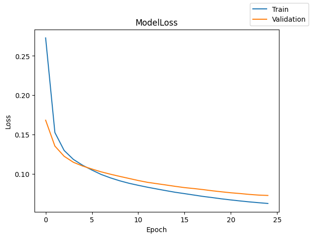

```python
plot(history_1,'loss')
```

```python
model_1_train_perf = model_perf_classify(model_1,X_train,y_train)
model_1_train_perf
```

```
469/469 ━━━━━━━━━━━━━━━━━━━━ 2s 3ms/step
```

|  | Accuracy | Recall | Precision | F1 Score |
| --- | --- | --- | --- | --- |
| 0 | 0.9858 | 0.887834 | 0.972802 | 0.925592 |

```python
model_1_val_perf = model_perf_classify(model_1,X_val,y_val)
model_1_val_perf
```

```
 18/157 ━━━━━━━━━━━━━━━━━━━━ 0s 3ms/step
```

```
157/157 ━━━━━━━━━━━━━━━━━━━━ 1s 5ms/step
```

|  | Accuracy | Recall | Precision | F1 Score |
| --- | --- | --- | --- | --- |
| 0 | 0.986 | 0.896105 | 0.966242 | 0.927952 |

```python
y_train_pred_1 = model_1.predict(X_train)
y_val_pred_1   = model_1.predict(X_val)
```

```
469/469 ━━━━━━━━━━━━━━━━━━━━ 1s 2ms/step
157/157 ━━━━━━━━━━━━━━━━━━━━ 0s 1ms/step
```

```python
print("Classification Report - Train dataset Model 1",end="\n\n")
cr_train_model_1 = classification_report(y_train,y_train_pred_1>0.5)
print(cr_train_model_1)
```

```
Classification Report - Train dataset Model 1

              precision    recall  f1-score   support

         0.0       0.99      1.00      0.99     14168
         1.0       0.96      0.78      0.86       832

    accuracy                           0.99     15000
   macro avg       0.97      0.89      0.93     15000
weighted avg       0.99      0.99      0.99     15000
```

```python
print("Classification Report - Validation dataset Model 1",end="\n\n")
cr_val_model_1 = classification_report(y_val,y_val_pred_1>0.5)
print(cr_val_model_1)
```

```
Classification Report - Validation dataset Model 1

              precision    recall  f1-score   support

         0.0       0.99      1.00      0.99      4722
         1.0       0.94      0.79      0.86       278

    accuracy                           0.99      5000
   macro avg       0.97      0.90      0.93      5000
weighted avg       0.99      0.99      0.99      5000
```

## Model 2

```python
tf.keras.backend.clear_session()
```

```python
model_2 = Sequential()
model_2.add(Dense(16,activation='relu',input_dim=X_train.shape[1]))
model_2.add(Dropout(0.5))
model_2.add(Dense(8,activation='relu'))
model_2.add(Dense(8,activation='relu'))
model_2.add(Dense(1,activation='sigmoid'))
```

```python
model_2.summary()
```

```
Model: "sequential"
```

```
┏━━━━━━━━━━━━━━━━━━━━━━━━━━━━━━━━━┳━━━━━━━━━━━━━━━━━━━━━━━━┳━━━━━━━━━━━━━━━┓
┃ Layer (type)                    ┃ Output Shape           ┃       Param # ┃
┡━━━━━━━━━━━━━━━━━━━━━━━━━━━━━━━━━╇━━━━━━━━━━━━━━━━━━━━━━━━╇━━━━━━━━━━━━━━━┩
│ dense (Dense)                   │ (None, 16)             │           656 │
├─────────────────────────────────┼────────────────────────┼───────────────┤
│ dropout (Dropout)               │ (None, 16)             │             0 │
├─────────────────────────────────┼────────────────────────┼───────────────┤
│ dense_1 (Dense)                 │ (None, 8)              │           136 │
├─────────────────────────────────┼────────────────────────┼───────────────┤
│ dense_2 (Dense)                 │ (None, 8)              │            72 │
├─────────────────────────────────┼────────────────────────┼───────────────┤
│ dense_3 (Dense)                 │ (None, 1)              │             9 │
└─────────────────────────────────┴────────────────────────┴───────────────┘
```

```
 Total params: 873 (3.41 KB)
```

```
 Trainable params: 873 (3.41 KB)
```

```
 Non-trainable params: 0 (0.00 B)
```

```python
optimizer = tf.keras.optimizers.SGD()
model_2.compile(loss='binary_crossentropy',optimizer=optimizer,metrics=['recall'])
```

```python
start = time.time()
history_2 = model_2.fit(X_train,y_train,validation_data=(X_val,y_val),batch_size=batch_size,epochs=epochs)
end   = time.time()
```

```
235/235 ━━━━━━━━━━━━━━━━━━━━ 6s 15ms/step - loss: 0.3322 - recall: 0.0465 - val_loss: 0.1904 - val_recall: 0.0000e+00
235/235 ━━━━━━━━━━━━━━━━━━━━ 2s 7ms/step - loss: 0.2126 - recall: 0.0015 - val_loss: 0.1615 - val_recall: 0.0000e+00
235/235 ━━━━━━━━━━━━━━━━━━━━ 2s 8ms/step - loss: 0.1920 - recall: 0.0228 - val_loss: 0.1474 - val_recall: 0.0612
235/235 ━━━━━━━━━━━━━━━━━━━━ 1s 5ms/step - loss: 0.1785 - recall: 0.0564 - val_loss: 0.1371 - val_recall: 0.1763
235/235 ━━━━━━━━━━━━━━━━━━━━ 1s 6ms/step - loss: 0.1574 - recall: 0.1019 - val_loss: 0.1302 - val_recall: 0.2698
235/235 ━━━━━━━━━━━━━━━━━━━━ 1s 5ms/step - loss: 0.1546 - recall: 0.1599 - val_loss: 0.1244 - val_recall: 0.3201
235/235 ━━━━━━━━━━━━━━━━━━━━ 1s 5ms/step - loss: 0.1501 - recall: 0.1897 - val_loss: 0.1194 - val_recall: 0.4281
235/235 ━━━━━━━━━━━━━━━━━━━━ 2s 9ms/step - loss: 0.1467 - recall: 0.2733 - val_loss: 0.1154 - val_recall: 0.4353
235/235 ━━━━━━━━━━━━━━━━━━━━ 2s 8ms/step - loss: 0.1408 - recall: 0.2701 - val_loss: 0.1123 - val_recall: 0.4388
235/235 ━━━━━━━━━━━━━━━━━━━━ 2s 7ms/step - loss: 0.1348 - recall: 0.3064 - val_loss: 0.1108 - val_recall: 0.4712
235/235 ━━━━━━━━━━━━━━━━━━━━ 2s 7ms/step - loss: 0.1292 - recall: 0.3479 - val_loss: 0.1088 - val_recall: 0.4676
235/235 ━━━━━━━━━━━━━━━━━━━━ 2s 7ms/step - loss: 0.1318 - recall: 0.3074 - val_loss: 0.1079 - val_recall: 0.4748
235/235 ━━━━━━━━━━━━━━━━━━━━ 2s 7ms/step - loss: 0.1237 - recall: 0.3635 - val_loss: 0.1059 - val_recall: 0.4928
235/235 ━━━━━━━━━━━━━━━━━━━━ 2s 6ms/step - loss: 0.1194 - recall: 0.3330 - val_loss: 0.1039 - val_recall: 0.5144
235/235 ━━━━━━━━━━━━━━━━━━━━ 2s 7ms/step - loss: 0.1187 - recall: 0.4143 - val_loss: 0.1027 - val_recall: 0.5288
235/235 ━━━━━━━━━━━━━━━━━━━━ 2s 7ms/step - loss: 0.1196 - recall: 0.3737 - val_loss: 0.1013 - val_recall: 0.5216
235/235 ━━━━━━━━━━━━━━━━━━━━ 2s 7ms/step - loss: 0.1255 - recall: 0.4188 - val_loss: 0.0998 - val_recall: 0.5324
235/235 ━━━━━━━━━━━━━━━━━━━━ 2s 7ms/step - loss: 0.1243 - recall: 0.4078 - val_loss: 0.0987 - val_recall: 0.5576
235/235 ━━━━━━━━━━━━━━━━━━━━ 2s 7ms/step - loss: 0.1130 - recall: 0.4000 - val_loss: 0.0986 - val_recall: 0.5504
235/235 ━━━━━━━━━━━━━━━━━━━━ 2s 7ms/step - loss: 0.1158 - recall: 0.4113 - val_loss: 0.0975 - val_recall: 0.5827
235/235 ━━━━━━━━━━━━━━━━━━━━ 2s 7ms/step - loss: 0.1198 - recall: 0.4447 - val_loss: 0.0959 - val_recall: 0.5755
235/235 ━━━━━━━━━━━━━━━━━━━━ 2s 7ms/step - loss: 0.1234 - recall: 0.4250 - val_loss: 0.0949 - val_recall: 0.5863
235/235 ━━━━━━━━━━━━━━━━━━━━ 2s 7ms/step - loss: 0.1147 - recall: 0.4362 - val_loss: 0.0943 - val_recall: 0.6187
235/235 ━━━━━━━━━━━━━━━━━━━━ 2s 7ms/step - loss: 0.1172 - recall: 0.4533 - val_loss: 0.0932 - val_recall: 0.6043
235/235 ━━━━━━━━━━━━━━━━━━━━ 2s 7ms/step - loss: 0.1104 - recall: 0.4882 - val_loss: 0.0926 - val_recall: 0.6259
```

```python
print("Time taken in seconds",end-start)
```

```
Time taken in seconds 45.26768732070923
```

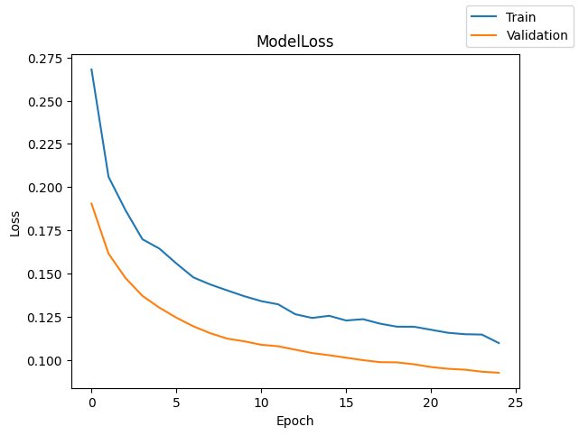

```python
plot(history_2,'loss')
```

```python
model_2_train_perf = model_perf_classify(model_2,X_train,y_train)
model_2_train_perf
```

```
469/469 ━━━━━━━━━━━━━━━━━━━━ 2s 3ms/step
```

|  | Accuracy | Recall | Precision | F1 Score |
| --- | --- | --- | --- | --- |
| 0 | 0.974867 | 0.794367 | 0.953281 | 0.854917 |

```python
model_2_val_perf = model_perf_classify(model_2,X_val,y_val)
model_2_val_perf
```

```
157/157 ━━━━━━━━━━━━━━━━━━━━ 1s 4ms/step
```

|  | Accuracy | Recall | Precision | F1 Score |
| --- | --- | --- | --- | --- |
| 0 | 0.9768 | 0.811679 | 0.95694 | 0.868918 |

```python
y_train_pred_2 = model_2.predict(X_train)
y_val_pred_2   = model_2.predict(X_val)
```

```
469/469 ━━━━━━━━━━━━━━━━━━━━ 1s 2ms/step
157/157 ━━━━━━━━━━━━━━━━━━━━ 0s 2ms/step
```

```python
print("Classification Report - Train dataset Model 2",end="\n\n")
cr_train_model_2 = classification_report(y_train,y_train_pred_2>0.5)
print(cr_train_model_2)
```

[output not shown]

```python
print("Classification Report - Validation dataset Model 2",end="\n\n")
cr_val_model_2 = classification_report(y_val,y_val_pred_2>0.5)
print(cr_val_model_2)
```

```
Classification Report - Validation dataset Model 2

              precision    recall  f1-score   support

         0.0       0.98      1.00      0.99      4722
         1.0       0.94      0.63      0.75       278

    accuracy                           0.98      5000
   macro avg       0.96      0.81      0.87      5000
weighted avg       0.98      0.98      0.97      5000
```

- It is performing well on the validation set indicating less loss in indicating the correct information compared to the previous model

## Model 3

As we have are dealing with an imbalance in class distribution, we should also be using class weights to allow the model to give proportionally more importance to the minority class.

```python
cw = (y_train.shape[0]) / np.bincount(y_train.astype(int))

cw_dict = {}
for i in range(cw.shape[0]):
    cw_dict[i] = cw[i]

cw_dict
```

```
{0: np.float64(1.0587238848108413), 1: np.float64(18.028846153846153)}
```

```python
tf.keras.backend.clear_session()
```

```python
model_3 = Sequential()
model_3.add(Dense(16,activation='relu',input_dim=X_train.shape[1]))
model_3.add(Dropout(0.5))
model_3.add(Dense(8,activation='relu'))
model_3.add(Dense(8,activation='relu'))
model_3.add(Dense(1,activation='sigmoid'))
```

```python
model_3.summary()
```

```
Model: "sequential"
```

```
┏━━━━━━━━━━━━━━━━━━━━━━━━━━━━━━━━━┳━━━━━━━━━━━━━━━━━━━━━━━━┳━━━━━━━━━━━━━━━┓
┃ Layer (type)                    ┃ Output Shape           ┃       Param # ┃
┡━━━━━━━━━━━━━━━━━━━━━━━━━━━━━━━━━╇━━━━━━━━━━━━━━━━━━━━━━━━╇━━━━━━━━━━━━━━━┩
│ dense (Dense)                   │ (None, 16)             │           656 │
├─────────────────────────────────┼────────────────────────┼───────────────┤
│ dropout (Dropout)               │ (None, 16)             │             0 │
├─────────────────────────────────┼────────────────────────┼───────────────┤
│ dense_1 (Dense)                 │ (None, 8)              │           136 │
├─────────────────────────────────┼────────────────────────┼───────────────┤
│ dense_2 (Dense)                 │ (None, 8)              │            72 │
├─────────────────────────────────┼────────────────────────┼───────────────┤
│ dense_3 (Dense)                 │ (None, 1)              │             9 │
└─────────────────────────────────┴────────────────────────┴───────────────┘
```

```
 Total params: 873 (3.41 KB)
```

```
 Trainable params: 873 (3.41 KB)
```

```
 Non-trainable params: 0 (0.00 B)
```

```python
optimizer = tf.keras.optimizers.SGD()
model_3.compile(loss='binary_crossentropy',optimizer=optimizer,metrics=['recall'])
```

```python
start = time.time()
history_3 = model_3.fit(X_train,y_train,validation_data=(X_val,y_val),batch_size=batch_size,epochs=epochs,class_weight=cw_dict)
end   = time.time()
```

```
235/235 ━━━━━━━━━━━━━━━━━━━━ 5s 16ms/step - loss: 1.2708 - recall: 0.5796 - val_loss: 0.4626 - val_recall: 0.8129
235/235 ━━━━━━━━━━━━━━━━━━━━ 1s 6ms/step - loss: 0.9621 - recall: 0.7901 - val_loss: 0.4373 - val_recall: 0.8417
235/235 ━━━━━━━━━━━━━━━━━━━━ 1s 6ms/step - loss: 0.8697 - recall: 0.7861 - val_loss: 0.2810 - val_recall: 0.8273
235/235 ━━━━━━━━━━━━━━━━━━━━ 1s 6ms/step - loss: 0.7519 - recall: 0.8066 - val_loss: 0.2990 - val_recall: 0.8525
235/235 ━━━━━━━━━━━━━━━━━━━━ 2s 7ms/step - loss: 0.6864 - recall: 0.8213 - val_loss: 0.3069 - val_recall: 0.8633
235/235 ━━━━━━━━━━━━━━━━━━━━ 1s 6ms/step - loss: 0.6820 - recall: 0.8315 - val_loss: 0.3065 - val_recall: 0.8777
235/235 ━━━━━━━━━━━━━━━━━━━━ 1s 6ms/step - loss: 0.6433 - recall: 0.8412 - val_loss: 0.2717 - val_recall: 0.8741
235/235 ━━━━━━━━━━━━━━━━━━━━ 1s 6ms/step - loss: 0.6278 - recall: 0.8252 - val_loss: 0.2515 - val_recall: 0.8597
235/235 ━━━━━━━━━━━━━━━━━━━━ 1s 6ms/step - loss: 0.6011 - recall: 0.8494 - val_loss: 0.2783 - val_recall: 0.8777
235/235 ━━━━━━━━━━━━━━━━━━━━ 2s 6ms/step - loss: 0.6608 - recall: 0.8135 - val_loss: 0.2279 - val_recall: 0.8813
235/235 ━━━━━━━━━━━━━━━━━━━━ 1s 6ms/step - loss: 0.6049 - recall: 0.8480 - val_loss: 0.2142 - val_recall: 0.8561
235/235 ━━━━━━━━━━━━━━━━━━━━ 1s 6ms/step - loss: 0.5498 - recall: 0.8687 - val_loss: 0.2384 - val_recall: 0.8705
235/235 ━━━━━━━━━━━━━━━━━━━━ 2s 6ms/step - loss: 0.6005 - recall: 0.8459 - val_loss: 0.2046 - val_recall: 0.8633
235/235 ━━━━━━━━━━━━━━━━━━━━ 1s 6ms/step - loss: 0.5486 - recall: 0.8415 - val_loss: 0.2179 - val_recall: 0.8813
235/235 ━━━━━━━━━━━━━━━━━━━━ 1s 6ms/step - loss: 0.6031 - recall: 0.8414 - val_loss: 0.2217 - val_recall: 0.8705
235/235 ━━━━━━━━━━━━━━━━━━━━ 1s 6ms/step - loss: 0.5485 - recall: 0.8653 - val_loss: 0.2475 - val_recall: 0.8777
235/235 ━━━━━━━━━━━━━━━━━━━━ 1s 6ms/step - loss: 0.6094 - recall: 0.8326 - val_loss: 0.2161 - val_recall: 0.8777
235/235 ━━━━━━━━━━━━━━━━━━━━ 1s 5ms/step - loss: 0.5631 - recall: 0.8506 - val_loss: 0.2399 - val_recall: 0.8777
235/235 ━━━━━━━━━━━━━━━━━━━━ 1s 5ms/step - loss: 0.4956 - recall: 0.8893 - val_loss: 0.1989 - val_recall: 0.8741
235/235 ━━━━━━━━━━━━━━━━━━━━ 1s 6ms/step - loss: 0.5543 - recall: 0.8428 - val_loss: 0.2305 - val_recall: 0.8813
235/235 ━━━━━━━━━━━━━━━━━━━━ 1s 6ms/step - loss: 0.5375 - recall: 0.8409 - val_loss: 0.2389 - val_recall: 0.8777
235/235 ━━━━━━━━━━━━━━━━━━━━ 1s 6ms/step - loss: 0.5774 - recall: 0.8533 - val_loss: 0.2022 - val_recall: 0.8705
235/235 ━━━━━━━━━━━━━━━━━━━━ 1s 5ms/step - loss: 0.5352 - recall: 0.8547 - val_loss: 0.2049 - val_recall: 0.8705
235/235 ━━━━━━━━━━━━━━━━━━━━ 1s 5ms/step - loss: 0.5569 - recall: 0.8488 - val_loss: 0.1968 - val_recall: 0.8669
235/235 ━━━━━━━━━━━━━━━━━━━━ 1s 5ms/step - loss: 0.5486 - recall: 0.8416 - val_loss: 0.2127 - val_recall: 0.8777
```

```python
print("Time taken in seconds",end-start)
```

```
Time taken in seconds 39.648383140563965
```

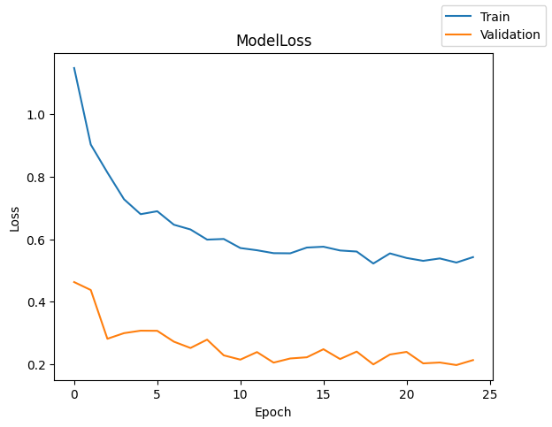

```python
plot(history_3,'loss')
```

```python
model_3_train_perf = model_perf_classify(model_3,X_train,y_train)
model_3_train_perf
```

```
469/469 ━━━━━━━━━━━━━━━━━━━━ 2s 3ms/step
```

|  | Accuracy | Recall | Precision | F1 Score |
| --- | --- | --- | --- | --- |
| 0 | 0.9662 | 0.935723 | 0.816183 | 0.864636 |

```python
model_3_val_perf = model_perf_classify(model_3,X_val,y_val)
model_3_val_perf
```

```
157/157 ━━━━━━━━━━━━━━━━━━━━ 1s 3ms/step
```

|  | Accuracy | Recall | Precision | F1 Score |
| --- | --- | --- | --- | --- |
| 0 | 0.965 | 0.923919 | 0.813199 | 0.858653 |

```python
y_train_pred_3 = model_3.predict(X_train)
y_val_pred_3   = model_3.predict(X_val)
```

```
469/469 ━━━━━━━━━━━━━━━━━━━━ 1s 2ms/step
157/157 ━━━━━━━━━━━━━━━━━━━━ 0s 2ms/step
```

```python
print("Classification Report - Train dataset Model 3",end="\n\n")
cr_train_model_3 = classification_report(y_train,y_train_pred_3>0.5)
print(cr_train_model_3)
```

```
Classification Report - Train dataset Model 3

              precision    recall  f1-score   support

         0.0       0.99      0.97      0.98     14168
         1.0       0.64      0.90      0.75       832

    accuracy                           0.97     15000
   macro avg       0.82      0.94      0.86     15000
weighted avg       0.97      0.97      0.97     15000
```

```python
print("Classification Report - Validation dataset Model 3",end="\n\n")
cr_val_model_3 = classification_report(y_val,y_val_pred_3>0.5)
print(cr_val_model_3)
```

```
Classification Report - Validation dataset Model 3

              precision    recall  f1-score   support

         0.0       0.99      0.97      0.98      4722
         1.0       0.63      0.88      0.74       278

    accuracy                           0.96      5000
   macro avg       0.81      0.92      0.86      5000
weighted avg       0.97      0.96      0.97      5000
```

- It is observed there is some osilations in the model
- While the model is performing better, the osilations can affect the predicted results

## Model 4

Since we have used only SGD optimizer till now, let's use another kind of optimizer and observe its impact on the model performmance.

```python
tf.keras.backend.clear_session()
```

```python
model_4 = Sequential()
model_4.add(Dense(16,activation='relu',input_dim=X_train.shape[1]))
model_4.add(Dense(8,activation='relu'))
model_4.add(Dense(1,activation='sigmoid'))
```

```python
model_4.summary()
```

```
Model: "sequential"
```

```
┏━━━━━━━━━━━━━━━━━━━━━━━━━━━━━━━━━┳━━━━━━━━━━━━━━━━━━━━━━━━┳━━━━━━━━━━━━━━━┓
┃ Layer (type)                    ┃ Output Shape           ┃       Param # ┃
┡━━━━━━━━━━━━━━━━━━━━━━━━━━━━━━━━━╇━━━━━━━━━━━━━━━━━━━━━━━━╇━━━━━━━━━━━━━━━┩
│ dense (Dense)                   │ (None, 16)             │           656 │
├─────────────────────────────────┼────────────────────────┼───────────────┤
│ dense_1 (Dense)                 │ (None, 8)              │           136 │
├─────────────────────────────────┼────────────────────────┼───────────────┤
│ dense_2 (Dense)                 │ (None, 1)              │             9 │
└─────────────────────────────────┴────────────────────────┴───────────────┘
```

```
 Total params: 801 (3.13 KB)
```

```
 Trainable params: 801 (3.13 KB)
```

```
 Non-trainable params: 0 (0.00 B)
```

```python
optimizer = tf.keras.optimizers.Adam()
model_4.compile(loss='binary_crossentropy',optimizer=optimizer,metrics=['recall'])
```

```python
start = time.time()
history_4 = model_4.fit(X_train,y_train,validation_data=(X_val,y_val),batch_size=batch_size,epochs=epochs)
end   = time.time()
```

```
235/235 ━━━━━━━━━━━━━━━━━━━━ 5s 14ms/step - loss: 0.7503 - recall: 0.4922 - val_loss: 0.1254 - val_recall: 0.4748
235/235 ━━━━━━━━━━━━━━━━━━━━ 2s 8ms/step - loss: 0.1143 - recall: 0.5076 - val_loss: 0.0914 - val_recall: 0.6978
235/235 ━━━━━━━━━━━━━━━━━━━━ 2s 7ms/step - loss: 0.0869 - recall: 0.6981 - val_loss: 0.0771 - val_recall: 0.7410
235/235 ━━━━━━━━━━━━━━━━━━━━ 2s 6ms/step - loss: 0.0764 - recall: 0.7580 - val_loss: 0.0716 - val_recall: 0.7950
235/235 ━━━━━━━━━━━━━━━━━━━━ 2s 6ms/step - loss: 0.0699 - recall: 0.7700 - val_loss: 0.0674 - val_recall: 0.8094
235/235 ━━━━━━━━━━━━━━━━━━━━ 2s 7ms/step - loss: 0.0592 - recall: 0.8073 - val_loss: 0.0662 - val_recall: 0.8201
235/235 ━━━━━━━━━━━━━━━━━━━━ 2s 7ms/step - loss: 0.0521 - recall: 0.8484 - val_loss: 0.0635 - val_recall: 0.8165
235/235 ━━━━━━━━━━━━━━━━━━━━ 2s 7ms/step - loss: 0.0533 - recall: 0.8195 - val_loss: 0.0622 - val_recall: 0.8165
235/235 ━━━━━━━━━━━━━━━━━━━━ 1s 6ms/step - loss: 0.0517 - recall: 0.8336 - val_loss: 0.0615 - val_recall: 0.8309
235/235 ━━━━━━━━━━━━━━━━━━━━ 1s 5ms/step - loss: 0.0450 - recall: 0.8484 - val_loss: 0.0599 - val_recall: 0.8273
235/235 ━━━━━━━━━━━━━━━━━━━━ 1s 4ms/step - loss: 0.0408 - recall: 0.8705 - val_loss: 0.0589 - val_recall: 0.8453
235/235 ━━━━━━━━━━━━━━━━━━━━ 1s 5ms/step - loss: 0.0491 - recall: 0.8630 - val_loss: 0.0589 - val_recall: 0.8417
235/235 ━━━━━━━━━━━━━━━━━━━━ 1s 5ms/step - loss: 0.0443 - recall: 0.8674 - val_loss: 0.0580 - val_recall: 0.8453
235/235 ━━━━━━━━━━━━━━━━━━━━ 1s 5ms/step - loss: 0.0430 - recall: 0.8679 - val_loss: 0.0576 - val_recall: 0.8489
235/235 ━━━━━━━━━━━━━━━━━━━━ 2s 7ms/step - loss: 0.0466 - recall: 0.8672 - val_loss: 0.0579 - val_recall: 0.8453
235/235 ━━━━━━━━━━━━━━━━━━━━ 1s 6ms/step - loss: 0.0428 - recall: 0.8686 - val_loss: 0.0572 - val_recall: 0.8417
235/235 ━━━━━━━━━━━━━━━━━━━━ 2s 7ms/step - loss: 0.0418 - recall: 0.8605 - val_loss: 0.0567 - val_recall: 0.8525
235/235 ━━━━━━━━━━━━━━━━━━━━ 1s 6ms/step - loss: 0.0363 - recall: 0.8773 - val_loss: 0.0567 - val_recall: 0.8381
235/235 ━━━━━━━━━━━━━━━━━━━━ 1s 6ms/step - loss: 0.0388 - recall: 0.8721 - val_loss: 0.0564 - val_recall: 0.8525
235/235 ━━━━━━━━━━━━━━━━━━━━ 1s 6ms/step - loss: 0.0387 - recall: 0.8911 - val_loss: 0.0562 - val_recall: 0.8489
235/235 ━━━━━━━━━━━━━━━━━━━━ 2s 7ms/step - loss: 0.0366 - recall: 0.8879 - val_loss: 0.0567 - val_recall: 0.8597
235/235 ━━━━━━━━━━━━━━━━━━━━ 1s 6ms/step - loss: 0.0381 - recall: 0.8771 - val_loss: 0.0562 - val_recall: 0.8489
235/235 ━━━━━━━━━━━━━━━━━━━━ 1s 6ms/step - loss: 0.0433 - recall: 0.8793 - val_loss: 0.0574 - val_recall: 0.8453
235/235 ━━━━━━━━━━━━━━━━━━━━ 2s 6ms/step - loss: 0.0344 - recall: 0.8923 - val_loss: 0.0567 - val_recall: 0.8489
235/235 ━━━━━━━━━━━━━━━━━━━━ 1s 6ms/step - loss: 0.0425 - recall: 0.8707 - val_loss: 0.0585 - val_recall: 0.8525
```

```python
print("Time taken in seconds",end-start)
```

```
Time taken in seconds 40.74363827705383
```

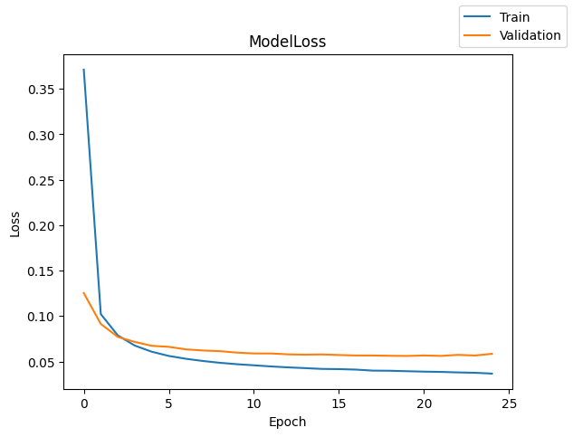

```python
plot(history_4,'loss')
```

```python
model_4_train_perf = model_perf_classify(model_4,X_train,y_train)
model_4_train_perf
```

```
469/469 ━━━━━━━━━━━━━━━━━━━━ 1s 3ms/step
```

|  | Accuracy | Recall | Precision | F1 Score |
| --- | --- | --- | --- | --- |
| 0 | 0.9934 | 0.944465 | 0.992087 | 0.966909 |

```python
model_4_val_perf = model_perf_classify(model_4,X_val,y_val)
model_4_val_perf
```

```
157/157 ━━━━━━━━━━━━━━━━━━━━ 1s 5ms/step
```

|  | Accuracy | Recall | Precision | F1 Score |
| --- | --- | --- | --- | --- |
| 0 | 0.9906 | 0.925624 | 0.983345 | 0.952415 |

```python
y_train_pred_4 = model_4.predict(X_train)
y_val_pred_4   = model_4.predict(X_val)
```

```
469/469 ━━━━━━━━━━━━━━━━━━━━ 2s 3ms/step
157/157 ━━━━━━━━━━━━━━━━━━━━ 0s 2ms/step
```

```python
print("Classification Report - Train dataset Model 4",end="\n\n")
cr_train_model_4 = classification_report(y_train,y_train_pred_4>0.5)
print(cr_train_model_4)
```

```
Classification Report - Train dataset Model 4

              precision    recall  f1-score   support

         0.0       0.99      1.00      1.00     14168
         1.0       0.99      0.89      0.94       832

    accuracy                           0.99     15000
   macro avg       0.99      0.94      0.97     15000
weighted avg       0.99      0.99      0.99     15000
```

```python
print("Classification Report - Validation dataset Model 4",end="\n\n")
cr_val_model_4 = classification_report(y_val,y_val_pred_4>0.5)
print(cr_val_model_4)
```

```
Classification Report - Validation dataset Model 4

              precision    recall  f1-score   support

         0.0       0.99      1.00      1.00      4722
         1.0       0.98      0.85      0.91       278

    accuracy                           0.99      5000
   macro avg       0.98      0.93      0.95      5000
weighted avg       0.99      0.99      0.99      5000
```

## Model 5

This time we will add more layers and dropout while using a different optimizer.

```python
tf.keras.backend.clear_session()
```

```python
model_5 = Sequential()
model_5.add(Dense(16,activation='relu',input_dim=X_train.shape[1]))
model_5.add(Dropout(0.5))
model_5.add(Dense(8,activation='relu'))
model_5.add(Dense(8,activation='relu'))
model_5.add(Dense(1,activation='sigmoid'))
```

```python
model_5.summary()
```

```
Model: "sequential"
```

```
┏━━━━━━━━━━━━━━━━━━━━━━━━━━━━━━━━━┳━━━━━━━━━━━━━━━━━━━━━━━━┳━━━━━━━━━━━━━━━┓
┃ Layer (type)                    ┃ Output Shape           ┃       Param # ┃
┡━━━━━━━━━━━━━━━━━━━━━━━━━━━━━━━━━╇━━━━━━━━━━━━━━━━━━━━━━━━╇━━━━━━━━━━━━━━━┩
│ dense (Dense)                   │ (None, 16)             │           656 │
├─────────────────────────────────┼────────────────────────┼───────────────┤
│ dropout (Dropout)               │ (None, 16)             │             0 │
├─────────────────────────────────┼────────────────────────┼───────────────┤
│ dense_1 (Dense)                 │ (None, 8)              │           136 │
├─────────────────────────────────┼────────────────────────┼───────────────┤
│ dense_2 (Dense)                 │ (None, 8)              │            72 │
├─────────────────────────────────┼────────────────────────┼───────────────┤
│ dense_3 (Dense)                 │ (None, 1)              │             9 │
└─────────────────────────────────┴────────────────────────┴───────────────┘
```

```
 Total params: 873 (3.41 KB)
```

```
 Trainable params: 873 (3.41 KB)
```

```
 Non-trainable params: 0 (0.00 B)
```

```python
optimizer = tf.keras.optimizers.Adam()
model_5.compile(loss='binary_crossentropy',optimizer=optimizer,metrics=['recall'])
```

```python
start = time.time()
history_5 = model_5.fit(X_train,y_train,validation_data=(X_val,y_val),batch_size=batch_size,epochs=epochs)
end   = time.time()
```

```
235/235 ━━━━━━━━━━━━━━━━━━━━ 7s 20ms/step - loss: 0.5705 - recall: 0.3418 - val_loss: 0.1501 - val_recall: 0.4820
235/235 ━━━━━━━━━━━━━━━━━━━━ 2s 7ms/step - loss: 0.1722 - recall: 0.2752 - val_loss: 0.1232 - val_recall: 0.5935
235/235 ━━━━━━━━━━━━━━━━━━━━ 2s 8ms/step - loss: 0.1475 - recall: 0.3623 - val_loss: 0.1070 - val_recall: 0.6259
235/235 ━━━━━━━━━━━━━━━━━━━━ 2s 7ms/step - loss: 0.1225 - recall: 0.4499 - val_loss: 0.0999 - val_recall: 0.6367
235/235 ━━━━━━━━━━━━━━━━━━━━ 2s 10ms/step - loss: 0.1121 - recall: 0.4638 - val_loss: 0.0963 - val_recall: 0.6799
235/235 ━━━━━━━━━━━━━━━━━━━━ 2s 7ms/step - loss: 0.1082 - recall: 0.5279 - val_loss: 0.0893 - val_recall: 0.7086
235/235 ━━━━━━━━━━━━━━━━━━━━ 2s 9ms/step - loss: 0.1116 - recall: 0.4929 - val_loss: 0.0833 - val_recall: 0.7374
235/235 ━━━━━━━━━━━━━━━━━━━━ 2s 9ms/step - loss: 0.1082 - recall: 0.5608 - val_loss: 0.0817 - val_recall: 0.7734
235/235 ━━━━━━━━━━━━━━━━━━━━ 2s 8ms/step - loss: 0.0967 - recall: 0.5793 - val_loss: 0.0774 - val_recall: 0.7626
235/235 ━━━━━━━━━━━━━━━━━━━━ 2s 7ms/step - loss: 0.1036 - recall: 0.5895 - val_loss: 0.0773 - val_recall: 0.7878
235/235 ━━━━━━━━━━━━━━━━━━━━ 2s 9ms/step - loss: 0.0950 - recall: 0.6076 - val_loss: 0.0777 - val_recall: 0.7842
235/235 ━━━━━━━━━━━━━━━━━━━━ 3s 11ms/step - loss: 0.0882 - recall: 0.6454 - val_loss: 0.0716 - val_recall: 0.7986
235/235 ━━━━━━━━━━━━━━━━━━━━ 2s 8ms/step - loss: 0.0865 - recall: 0.6253 - val_loss: 0.0736 - val_recall: 0.8201
235/235 ━━━━━━━━━━━━━━━━━━━━ 2s 8ms/step - loss: 0.0827 - recall: 0.6213 - val_loss: 0.0708 - val_recall: 0.8129
235/235 ━━━━━━━━━━━━━━━━━━━━ 2s 7ms/step - loss: 0.0860 - recall: 0.6510 - val_loss: 0.0674 - val_recall: 0.8129
235/235 ━━━━━━━━━━━━━━━━━━━━ 2s 6ms/step - loss: 0.0851 - recall: 0.6533 - val_loss: 0.0677 - val_recall: 0.8273
235/235 ━━━━━━━━━━━━━━━━━━━━ 2s 8ms/step - loss: 0.0834 - recall: 0.6905 - val_loss: 0.0661 - val_recall: 0.8345
235/235 ━━━━━━━━━━━━━━━━━━━━ 2s 9ms/step - loss: 0.0796 - recall: 0.7017 - val_loss: 0.0658 - val_recall: 0.8381
235/235 ━━━━━━━━━━━━━━━━━━━━ 2s 7ms/step - loss: 0.0764 - recall: 0.7245 - val_loss: 0.0671 - val_recall: 0.8345
235/235 ━━━━━━━━━━━━━━━━━━━━ 2s 8ms/step - loss: 0.0749 - recall: 0.6859 - val_loss: 0.0670 - val_recall: 0.8417
235/235 ━━━━━━━━━━━━━━━━━━━━ 2s 7ms/step - loss: 0.0850 - recall: 0.7050 - val_loss: 0.0657 - val_recall: 0.8345
235/235 ━━━━━━━━━━━━━━━━━━━━ 2s 8ms/step - loss: 0.0785 - recall: 0.6629 - val_loss: 0.0652 - val_recall: 0.8201
235/235 ━━━━━━━━━━━━━━━━━━━━ 2s 8ms/step - loss: 0.0772 - recall: 0.7137 - val_loss: 0.0636 - val_recall: 0.8201
235/235 ━━━━━━━━━━━━━━━━━━━━ 2s 8ms/step - loss: 0.0768 - recall: 0.7037 - val_loss: 0.0664 - val_recall: 0.8273
235/235 ━━━━━━━━━━━━━━━━━━━━ 2s 8ms/step - loss: 0.0770 - recall: 0.6976 - val_loss: 0.0674 - val_recall: 0.8165
```

```python
print("Time taken in seconds",end-start)
```

```
Time taken in seconds 53.296793699264526
```

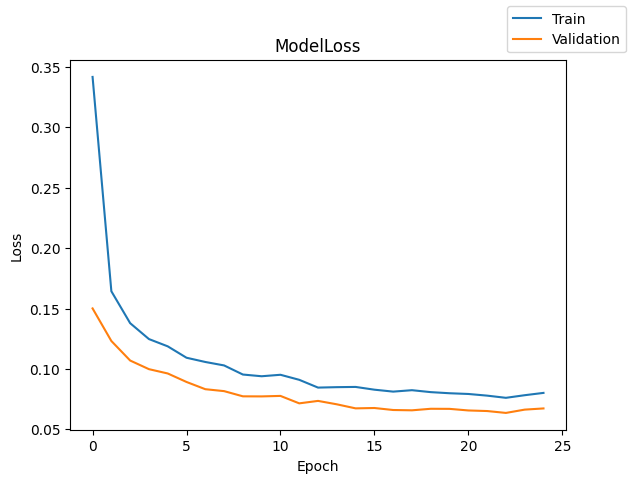

```python
plot(history_5,'loss')
```

```python
model_5_train_perf = model_perf_classify(model_5,X_train,y_train)
model_5_train_perf
```

```
469/469 ━━━━━━━━━━━━━━━━━━━━ 2s 3ms/step
```

|  | Accuracy | Recall | Precision | F1 Score |
| --- | --- | --- | --- | --- |
| 0 | 0.988933 | 0.919473 | 0.972213 | 0.94408 |

```python
model_5_val_perf = model_perf_classify(model_5,X_val,y_val)
model_5_val_perf
```

```
157/157 ━━━━━━━━━━━━━━━━━━━━ 1s 4ms/step
```

|  | Accuracy | Recall | Precision | F1 Score |
| --- | --- | --- | --- | --- |
| 0 | 0.9864 | 0.906473 | 0.959802 | 0.931279 |

```python
y_train_pred_5 = model_5.predict(X_train)
y_val_pred_5   = model_5.predict(X_val)
```

```
469/469 ━━━━━━━━━━━━━━━━━━━━ 1s 3ms/step
157/157 ━━━━━━━━━━━━━━━━━━━━ 0s 2ms/step
```

```python
print("Classification Report - Train dataset Model 5",end="\n\n")
cr_train_model_5 = classification_report(y_train,y_train_pred_5>0.5)
print(cr_train_model_5)
```

```
Classification Report - Train dataset Model 5

              precision    recall  f1-score   support

         0.0       0.99      1.00      0.99     14168
         1.0       0.95      0.84      0.89       832

    accuracy                           0.99     15000
   macro avg       0.97      0.92      0.94     15000
weighted avg       0.99      0.99      0.99     15000
```

```python
print("Classification Report - Validation dataset Model 5",end="\n\n")
cr_val_model_5 = classification_report(y_val,y_val_pred_5>0.5)
print(cr_val_model_5)
```

```
Classification Report - Validation dataset Model 5

              precision    recall  f1-score   support

         0.0       0.99      1.00      0.99      4722
         1.0       0.93      0.82      0.87       278

    accuracy                           0.99      5000
   macro avg       0.96      0.91      0.93      5000
weighted avg       0.99      0.99      0.99      5000
```

- The difference between the train and validation scores has remained the same
- Though the recall has reduced compared to the previous model, there is minimal loss observed

## Model 6

```python
tf.keras.backend.clear_session()
```

```python
model_6 = Sequential()
model_6.add(Dense(16,activation='relu',input_dim=X_train.shape[1]))
model_6.add(Dropout(0.5))
model_6.add(Dense(8,activation='relu'))
model_6.add(Dense(8,activation='relu'))
model_6.add(Dense(1,activation='sigmoid'))
```

```python
model_6.summary()
```

```
Model: "sequential"
```

```
┏━━━━━━━━━━━━━━━━━━━━━━━━━━━━━━━━━┳━━━━━━━━━━━━━━━━━━━━━━━━┳━━━━━━━━━━━━━━━┓
┃ Layer (type)                    ┃ Output Shape           ┃       Param # ┃
┡━━━━━━━━━━━━━━━━━━━━━━━━━━━━━━━━━╇━━━━━━━━━━━━━━━━━━━━━━━━╇━━━━━━━━━━━━━━━┩
│ dense (Dense)                   │ (None, 16)             │           656 │
├─────────────────────────────────┼────────────────────────┼───────────────┤
│ dropout (Dropout)               │ (None, 16)             │             0 │
├─────────────────────────────────┼────────────────────────┼───────────────┤
│ dense_1 (Dense)                 │ (None, 8)              │           136 │
├─────────────────────────────────┼────────────────────────┼───────────────┤
│ dense_2 (Dense)                 │ (None, 8)              │            72 │
├─────────────────────────────────┼────────────────────────┼───────────────┤
│ dense_3 (Dense)                 │ (None, 1)              │             9 │
└─────────────────────────────────┴────────────────────────┴───────────────┘
```

```
 Total params: 873 (3.41 KB)
```

```
 Trainable params: 873 (3.41 KB)
```

```
 Non-trainable params: 0 (0.00 B)
```

```python
optimizer = tf.keras.optimizers.SGD()
model_6.compile(loss='binary_crossentropy',optimizer=optimizer,metrics=['recall'])
```

```python
start = time.time()
history_6 = model_6.fit(X_train,y_train,validation_data=(X_val,y_val),batch_size=batch_size,epochs=epochs,class_weight=cw_dict)
end   = time.time()
```

```
235/235 ━━━━━━━━━━━━━━━━━━━━ 6s 17ms/step - loss: 1.2941 - recall: 0.6922 - val_loss: 0.4154 - val_recall: 0.7266
235/235 ━━━━━━━━━━━━━━━━━━━━ 2s 7ms/step - loss: 0.9580 - recall: 0.7430 - val_loss: 0.3243 - val_recall: 0.7950
235/235 ━━━━━━━━━━━━━━━━━━━━ 2s 6ms/step - loss: 0.8974 - recall: 0.7156 - val_loss: 0.2851 - val_recall: 0.8237
235/235 ━━━━━━━━━━━━━━━━━━━━ 2s 10ms/step - loss: 0.7706 - recall: 0.7791 - val_loss: 0.2659 - val_recall: 0.8489
235/235 ━━━━━━━━━━━━━━━━━━━━ 2s 8ms/step - loss: 0.6691 - recall: 0.8160 - val_loss: 0.2512 - val_recall: 0.8561
235/235 ━━━━━━━━━━━━━━━━━━━━ 2s 9ms/step - loss: 0.6295 - recall: 0.8304 - val_loss: 0.2446 - val_recall: 0.8525
235/235 ━━━━━━━━━━━━━━━━━━━━ 2s 9ms/step - loss: 0.5768 - recall: 0.8309 - val_loss: 0.2670 - val_recall: 0.8525
235/235 ━━━━━━━━━━━━━━━━━━━━ 2s 10ms/step - loss: 0.6275 - recall: 0.8378 - val_loss: 0.2516 - val_recall: 0.8597
235/235 ━━━━━━━━━━━━━━━━━━━━ 2s 7ms/step - loss: 0.5731 - recall: 0.8535 - val_loss: 0.2141 - val_recall: 0.8669
235/235 ━━━━━━━━━━━━━━━━━━━━ 2s 8ms/step - loss: 0.6023 - recall: 0.8280 - val_loss: 0.1977 - val_recall: 0.8669
235/235 ━━━━━━━━━━━━━━━━━━━━ 2s 7ms/step - loss: 0.5866 - recall: 0.8297 - val_loss: 0.1972 - val_recall: 0.8669
235/235 ━━━━━━━━━━━━━━━━━━━━ 2s 8ms/step - loss: 0.5891 - recall: 0.8429 - val_loss: 0.1694 - val_recall: 0.8633
235/235 ━━━━━━━━━━━━━━━━━━━━ 2s 7ms/step - loss: 0.5259 - recall: 0.8465 - val_loss: 0.2073 - val_recall: 0.8741
235/235 ━━━━━━━━━━━━━━━━━━━━ 2s 8ms/step - loss: 0.5589 - recall: 0.8397 - val_loss: 0.1849 - val_recall: 0.8705
235/235 ━━━━━━━━━━━━━━━━━━━━ 2s 7ms/step - loss: 0.5256 - recall: 0.8759 - val_loss: 0.1862 - val_recall: 0.8669
235/235 ━━━━━━━━━━━━━━━━━━━━ 2s 7ms/step - loss: 0.5358 - recall: 0.8503 - val_loss: 0.1897 - val_recall: 0.8777
235/235 ━━━━━━━━━━━━━━━━━━━━ 2s 7ms/step - loss: 0.5086 - recall: 0.8666 - val_loss: 0.2089 - val_recall: 0.8777
235/235 ━━━━━━━━━━━━━━━━━━━━ 2s 7ms/step - loss: 0.5581 - recall: 0.8364 - val_loss: 0.1794 - val_recall: 0.8633
235/235 ━━━━━━━━━━━━━━━━━━━━ 2s 8ms/step - loss: 0.5372 - recall: 0.8381 - val_loss: 0.2199 - val_recall: 0.8849
235/235 ━━━━━━━━━━━━━━━━━━━━ 2s 7ms/step - loss: 0.5477 - recall: 0.8545 - val_loss: 0.2026 - val_recall: 0.8741
235/235 ━━━━━━━━━━━━━━━━━━━━ 2s 8ms/step - loss: 0.4930 - recall: 0.8773 - val_loss: 0.2056 - val_recall: 0.8813
235/235 ━━━━━━━━━━━━━━━━━━━━ 2s 7ms/step - loss: 0.5564 - recall: 0.8463 - val_loss: 0.2006 - val_recall: 0.8777
235/235 ━━━━━━━━━━━━━━━━━━━━ 2s 7ms/step - loss: 0.5942 - recall: 0.8245 - val_loss: 0.1789 - val_recall: 0.8741
235/235 ━━━━━━━━━━━━━━━━━━━━ 2s 7ms/step - loss: 0.5677 - recall: 0.8310 - val_loss: 0.1686 - val_recall: 0.8777
235/235 ━━━━━━━━━━━━━━━━━━━━ 2s 7ms/step - loss: 0.5302 - recall: 0.8434 - val_loss: 0.1908 - val_recall: 0.8813
```

```python
print("Time taken in seconds",end-start)
```

```
Time taken in seconds 50.30856442451477
```

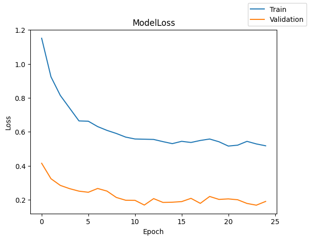

```python
plot(history_6,'loss')
```

```python
model_6_train_perf = model_perf_classify(model_6,X_train,y_train)
model_6_train_perf
```

```
469/469 ━━━━━━━━━━━━━━━━━━━━ 2s 3ms/step
```

|  | Accuracy | Recall | Precision | F1 Score |
| --- | --- | --- | --- | --- |
| 0 | 0.975733 | 0.939072 | 0.860994 | 0.895578 |

```python
model_6_val_perf = model_perf_classify(model_6,X_val,y_val)
model_6_val_perf
```

```
157/157 ━━━━━━━━━━━━━━━━━━━━ 1s 6ms/step
```

|  | Accuracy | Recall | Precision | F1 Score |
| --- | --- | --- | --- | --- |
| 0 | 0.9756 | 0.931224 | 0.86323 | 0.893829 |

```python
y_train_pred_6 = model_6.predict(X_train)
y_val_pred_6   = model_6.predict(X_val)
```

```
469/469 ━━━━━━━━━━━━━━━━━━━━ 1s 2ms/step
157/157 ━━━━━━━━━━━━━━━━━━━━ 0s 2ms/step
```

```python
print("Classification Report - Train dataset Model 6",end="\n\n")
cr_train_model_6= classification_report(y_train,y_train_pred_6>0.5)
print(cr_train_model_6)
```

```
Classification Report - Train dataset Model 6

              precision    recall  f1-score   support

         0.0       0.99      0.98      0.99     14168
         1.0       0.73      0.90      0.80       832

    accuracy                           0.98     15000
   macro avg       0.86      0.94      0.90     15000
weighted avg       0.98      0.98      0.98     15000
```

```python
print("Classification Report - Validation dataset Model 6",end="\n\n")
cr_val_model_6 = classification_report(y_val,y_val_pred_6>0.5)
print(cr_val_model_6)
```

```
Classification Report - Validation dataset Model 6

              precision    recall  f1-score   support

         0.0       0.99      0.98      0.99      4722
         1.0       0.73      0.88      0.80       278

    accuracy                           0.98      5000
   macro avg       0.86      0.93      0.89      5000
weighted avg       0.98      0.98      0.98      5000
```

- There are oscilations observed in the validation set
- The difference between the train and validation scores has reduced

# **Model Performance Comparison and Final Model Selection**

Now, in order to select the final model, we will compare the performances of all the models for the training and validation sets.

```python
models_train_comp_df = pd.concat(
    [
        model_0_train_perf.T,
        model_1_train_perf.T,
        model_2_train_perf.T,
        model_3_train_perf.T,
        model_4_train_perf.T,
        model_5_train_perf.T,
        model_6_train_perf.T
    ],
    axis=1
)
models_train_comp_df.columns = [
    "Model 0",
    "Model 1",
    "Model 2",
    "Model 3",
    "Model 4",
    "Model 5",
    "Model 6"
]
print("Comparison of training set performance")
models_train_comp_df
```

```
Comparison of training set performance
```

[output not shown]

```python
models_train_comp_df = pd.concat(
    [
        model_0_val_perf.T,
        model_1_val_perf.T,
        model_2_val_perf.T,
        model_3_val_perf.T,
        model_4_val_perf.T,
        model_5_val_perf.T,
        model_6_val_perf.T
    ],
    axis=1
)
models_train_comp_df.columns = [
    "Model 0",
    "Model 1",
    "Model 2",
    "Model 3",
    "Model 4",
    "Model 5",
    "Model 6"
]
print("Comparison of training set performance")
models_train_comp_df
```

```
Comparison of training set performance
```

[output not shown]

Now, let's check the performance of the final model on the test set.

```python
best_model = model_5
```

```python
best_model_test_perf =  model_perf_classify(best_model,X_test,y_test)
best_model_test_perf
```

```
157/157 ━━━━━━━━━━━━━━━━━━━━ 1s 8ms/step
```

|  | Accuracy | Recall | Precision | F1 Score |
| --- | --- | --- | --- | --- |
| 0 | 0.9812 | 0.850004 | 0.967197 | 0.899139 |

```python
y_test_pred_best = best_model.predict(X_test)

cr_test_best_model = classification_report(y_test,y_test_pred_best>0.5)
print(cr_test_best_model)
```

```
157/157 ━━━━━━━━━━━━━━━━━━━━ 1s 7ms/step
              precision    recall  f1-score   support

         0.0       0.98      1.00      0.99      4718
         1.0       0.95      0.70      0.81       282

    accuracy                           0.98      5000
   macro avg       0.97      0.85      0.90      5000
weighted avg       0.98      0.98      0.98      5000
```

# **Actionable Insights and Recommendations**

Write down some insights and business recommendations based on your observations.

- Due to insufficient information about the predictors V1 to V40, it is difficult to get more clarity about the variables and its purpose in the performance of component
- From the heatmap, it is observed there is a high correlation between variable V15 and V7 which may indicate they have a high dependency to each other which an help in provide more insight on performance of the generator. If one fails, it can indicate a repair so as to reduce the instances of replacement.
- Consider prioritizing the sensors that are more important to the functioning of the generators such as wind speed and temperature. This can help increase the logevity of the moving parts makingh them more durable.
- In addition to priorizing the important sensors, these sensors can be observed keenly by the model for any flactuations in readings by providing particular insights of the weather patterns and advicing the team when to reduce the generator performance there by protecting the important components
- While the model needs to learn, coming up with new sensors that can be an intermidiary between the existing sensors so as to provide a different perspective of information regarding a particular component or the generator can help in identifying and predicting what part needs maintenance rather than replacing the generator